SYSTEMATIC REVIEW

published: 26 July 2019

doi: 10.3389/fphys.2019.00961

Edited by:

Justin Dean,

The University of Auckland,

New Zealand

Reviewed by:

Max Berry,

University of Otago, New Zealand

Stephane Vladimir Sizonenko,

Geneva University Hospitals

(HUG), Switzerland

*Correspondence:

Manon J. N. L. Benders

m.benders@umcutrecht.nl

Specialty section:

This article was submitted to

Embryonic and Developmental

Physiology,

a section of the journal

Frontiers in Physiology

Received: 25 January 2019

Accepted: 11 July 2019

Published: 26 July 2019

Citation:

Hortensius LM, van Elburg RM,

Nijboer CH, Benders MJNL and de

Theije CGM (2019) Postnatal Nutrition

to Improve Brain Development in the

Preterm Infant: A Systematic Review

From Bench to Bedside.

Front. Physiol. 10:961.

doi: 10.3389/fphys.2019.00961

Postnatal Nutrition to Improve Brain

Development in the Preterm Infant: A

Systematic Review From Bench to

Bedside

Lisa M. Hortensius <sup>1</sup>, Ruurd M. van Elburg <sup>2,3</sup>, Cora H. Nijboer <sup>4</sup>, Manon J. N. L. Benders <sup>1,4</sup>*

and Caroline G. M. de Theije <sup>4</sup>

1 Department of Neonatology, University Medical Center Utrecht, Utrecht University, Utrecht, Netherlands, 2 Emma Children’s

Hospital, Amsterdam UMC, University of Amsterdam, Amsterdam, Netherlands, <sup>3</sup>Danone Nutricia Research, Utrecht,

Netherlands, <sup>4</sup>Laboratory of Neuroimmunology and Developmental Origins of Disease, University Medical Center Utrecht,

Utrecht University, Utrecht, Netherlands

Background: Preterm infants are at high risk for Encephalopathy of Prematurity and

successive adverse neurodevelopmental outcome. Adequate nutrition is crucial for

healthy brain development. Maternal breast milk is ﬁrst choice of post-natal enteral

nutrition for preterm infants. However, breast milk contains insufﬁcient nutrient quantities

to meet the greater nutritional needs of preterm infants, meaning that supplementation

is recommended.

Aim: To provide an overview of current literature on potential nutritional interventions

for improvement of neurodevelopmental outcome in preterm infants, by taking a bench

to bedside approach from pre-clinical models of neonatal brain injury to randomized

controlled clinical trials (RCTs) in preterm infants.

Methods: Separate clinical and pre-clinical searches were performed in Medline and

Embase for English written papers published between 08/2008 and 08/2018 that studied

a single nutritional component. Papers were included if one of the following components

was studied: lipids, carbohydrates, proteins, vitamins, minerals, probiotics, prebiotics,

oligosaccharides, fatty acids, or amino acids, with brain injury, brain development or

neurodevelopmental outcome as outcome measure in preterm infants (gestational age

<32 weeks and/or birth weight <1,500 g) or in animal models of neonatal brain injury.

Results:

In total, 2,671 pre-clinical studies and 852 RCTs were screened, of

which 24 pre-clinical and 22 RCTs were included in this review. In these trials

supplementation with amino acids and protein, lipids, probiotics (only clinical), prebiotics

(only clinical), vitamins, and minerals was studied. All included pre-clinical studies

show positive effect of supplementation on brain injury and/or neurodevelopment.

Although some nutrients, such as glutamine, show promising short term outcome

in clinical studies, no evident long term effect of any supplemented nutrient

was found. Main limitations were inclusion of studies no older than 10 years at

time of search and studies that focused on single nutritional components only.

Conclusion:

Even though many pre-clinical trials demonstrate promising effects

of

different

nutritional

interventions

on

reducing

brain

injury

and/or

improving

neurodevelopmental outcome, these positive effects have so far not evidently been

demonstrated in RCTs. More clinically relevant animal models and long term follow up

after clinical trials are needed to move novel nutritional therapies from bench to bedside

of preterm infants.

Keywords: nutrition, preterm infants, animal models, clinical, pre-clinical, brain injury, neurodevelopment

INTRODUCTION

Preterm birth is commonly deﬁned as any birth before 37

completed weeks of gestation and has been estimated to account

for 10% of all births (Liu et al., 2012). Over the past decade,

advances in neonatal care have led to decreased mortality

of preterm infants in Western society (Euro-Peristat Project

with SCPE EUROCAT, 2013). Therefore, the main focus of

neonatal care has changed from reducing mortality to reducing

long-term morbidity. Brain injury and successive impaired

neurodevelopmental outcome is a major morbidity in the

preterm infant (Twilhaar et al., 2018c). Despite improvements

in preventative strategies (e.g., prenatal steroids) and enhanced

neuromonitoring, the rate of neurodevelopmental impairments

remains high and is estimated to be 25% in extremely preterm

infants born before 28 weeks of gestation (Glass et al., 2015).

During the third trimester of gestation, the brain undergoes

a rapid trajectory of growth. Brain growth from 30 to 40 weeks

of gestation is greatest in the cerebellum, which increases 258%

in size (Kersbergen et al., 2016). The total brain volume is

increased by 140% during these 10 weeks. Third trimester brain

volumes have been shown to be reduced in preterm infants

compared to healthy control fetuses, and growth trajectories

were slower in cerebrum, cerebellum, brain stem and intracranial

cavity (Bouyssi-Kobar et al., 2016). Injury to the preterm brain

is commonly deﬁned as “Encephalopathy of Prematurity” (EoP)

and includes diﬀerent pathologies. The most commonly observed

pathology is cerebral white matter injury (WMI), which can

present as diﬀuse or as punctate, cystic, or hemorrhagic lesions.

In addition, also germinal matrix-intraventricular hemorrhages,

and cerebellar disturbances are frequently observed in the

preterm brain (van Tilborg et al., 2016). The pre- and post-

natal conditions leading to EoP are typically associated with

cerebral oxygen ﬂuctuations and systemic inﬂammation (van

Tilborg et al., 2016). These risk factors are thought to lead to an

arrest in oligodendrocyte maturation, followed by a myelination

failure of neuronal axons (van Tilborg et al., 2018b), resulting in

reduced neuronal connectivity and brain volume. Both neuronal

connectivity and brain volume are important predictors of

neurodevelopmental outcome in the preterm infant.

**Abbreviations:** AA, arachidonic acid; BSITD, Bayley Scales of Infant and Toddler

Development; DHA, docosahexaenoic acid; EoP, Encephalopathy of Prematurity;

EPA, eicosapentaenoic acid; FA, fractional anisotropy; HIE, hypoxic-ischemic

encephalopathy; HMF, human milk fortiﬁer; PLIC, posterior limb of the internal

capsule; RCT, randomized controlled trial; WMI, white matter injury.

As the rapidly growing brain at this stage in particular is

vulnerable for nutrient insuﬃciencies (Georgieﬀ, 2007), one may

hypothesize that nutrient intake by preterm infants may predict

brain growth and possibly neurodevelopmental outcomes. Intake

quantities of selective and total nutrients during early life of

preterm infants were shown to be positively associated with

increased head circumference growth (Dabydeen et al., 2008),

brain growth and basal nuclei volumes (Coviello et al., 2018;

Schneider et al., 2018). In addition, nutrient intake was also

positively correlated with higher fractional anisotropy (FA)

values in selected white matter tracts (Schneider et al., 2018), such

as the posterior limb of internal capsule (PLIC) (Coviello et al.,

2018), and with greater axonal diameters in the corticospinal

tract, indicating improved white matter integrity (Dabydeen

et al., 2008). Moreover, cumulative protein intake was positively

associated with higher cognitive and motor scores (Coviello

et al., 2018). In a diﬀerent study, it was demonstrated that

ﬁrst week protein and energy intakes were associated with

improved developmental outcomes in extremely preterm born

infants (Stephens et al., 2009). Together, these studies highlight

the importance of adequate nutrition and the balance between

protein, fat, and caloric content for early life brain development

of the preterm infant.

Currently, “adequate” nutrition for the preterm infant is

designed to “provide nutrients to approximate the rate of growth

and composition of weight gain for a normal fetus of the same

post-menstrual age and to maintain normal concentrations of

blood and tissue nutrients” (American Academy of Pediatrics,

2009). The preferred source of nutrition for preterm infants is

human milk from the infant’s own mother. However, it has been

long known that very/extremely preterm infants fed exclusively

breast milk cannot match intrauterine growth patterns and

may end up with extra uterine growth restriction. Therefore,

human milk is fortiﬁed with a Human Milk Fortiﬁer (HMF)

to enhance protein, caloric, vitamin and mineral intake. It

is important to note that extremely preterm infants are fed

fortiﬁed human milk, regardless of the actual content of the

human milk itself. From a Cochrane systematic review on the

use of HMF for preterm nutrition it was concluded that HMF

slightly increased in-hospital growth rates, but there was not

enough evidence to suggest that feeding preterm infants with a

standard amount of multi-nutrient fortiﬁed breast milk improves

important developmental outcomes (Brown et al., 2016). This

highlights the knowledge gap between what we currently feed the

preterm infant and what has actually been proven to be eﬀective

on developmental outcome. The importance of this issue has

been acknowledged by the World Health Organization (WHO).

In their recommendations on interventions to improve preterm

birth outcomes (World Health Organization, 2015), they pose the

following two questions as research priorities: (1) “What are the

optimal feeding methods for preterm infants with birth weight

<1,200 g?” and (2) “Is there a role for total parenteral nutrition

in the management of preterm infants?”

In recent years, there has been increased interest in how

to optimally feed the preterm infant, especially with respect to

neurodevelopment. Randomized controlled trials (RCTs) have

been focused on increasing protein, caloric, or fat intake and

on supplementation with speciﬁc nutritional components. Also

in pre-clinical studies, the potential mechanisms in which

various speciﬁc nutritional supplements can protect or treat the

neonatal brain from injury have been investigated in recent years.

Therefore, this systematic review aimed to provide an overview

of the current literature on potential nutritional interventions

for the improvement of neurodevelopmental outcome in preterm

infants, by taking a bench to bedside approach from pre-clinical

models of neonatal brain injury to randomized clinical trials in

preterm infants.

METHODS

Search

This systematic review was conducted according to PRISMA

guidelines (Moher et al., 2009). To evaluate the clinical

impact of nutritional interventions on brain development and

neurodevelopmental outcome, Embase and Medline (Pubmed)

were searched on August 15 2018 for RCTs published in

the last 10 years. The search was divided into a pre-clinical

search and a clinical search. For the pre-clinical search,

studies were included if they met the following inclusion

criteria: (1) neonatal brain injury induced by hypoxia, ischemia,

inﬂammation and/or hyperoxia, induced during gestation or

in the neonatal period (no later than post-natal day 10 (P10),

which corresponds to near term human neurodevelopment)

(Salmaso et al., 2014), (2) post-natal intervention with a

nutritional component that started between birth and weaning

(P21) with one of the following nutritional components:

lipids, carbohydrates, proteins, vitamins, minerals, probiotics,

prebiotics, oligosaccharides, fatty acids or amino acids, and (3)

brain injury or neurodevelopment as outcome measure. Studies

were excluded if (1) the article was written in a language

other than English (2) the article was published over 10 years

ago at time of search or if (3) more than one nutritional

component was studied as the aim of this review was to study

individual nutritional components. Embase and Medline were

both searched with similar search strategies. For example, for

Medline the following search was used:

(((((“Brain

Injuries”[Mesh])

OR

((((“Brain”[Mesh])

OR

brain[Title/Abstract]))

AND

((damage[Title/Abstract])

OR

injury[Title/Abstract])))) AND ((“animal experimentation”[MeSH

Terms]

OR

“models,

animal”[MeSH

Terms]

OR

“invertebrates”[MeSH

Terms]

OR

“Animals”[Mesh:noexp]

OR

“animal

population

groups”[MeSH

Terms]

OR

“Mice”[Mesh]

OR

“Rats”[Mesh]

OR

“Rodentia”[Mesh]

OR

mice[Title/Abstract]

OR

mouse[Title/Abstract]

OR

rodent[Title/Abstract]

OR

rodents[Title/Abstract]

OR

rat[Title/Abstract]

OR

rats[Title/Abstract]

OR

murine[tiab]

OR

“Papio”[Mesh]

OR

baboon[Title/Abstract]

OR

baboons[Title/Abstract] OR marmoset[tiab] OR marmosets[tiab]

OR monkey[tiab] OR monkeys[tiab] OR primate[Title/Abstract]

OR

primates[Title/Abstract]

OR

“Primates”[Mesh]

OR

“Sheep,

Domestic”[Mesh]

OR

sheep[Title/Abstract]

OR

lamb[Title/Abstract]

OR

lambs[Title/Abstract]

OR

pigs[tiab]

OR pig[tiab] OR swine[tiab] OR swines[tiab] OR piglets[tiab] OR

piglet[tiab] OR boar[tiab] OR boars[tiab] OR “guinea pigs”[tiab]

OR

“guinea

pig”[tiab]

OR

rabbits[tiab]

OR

rabbit[tiab])))

AND (((“Infant, Low Birth Weight”[Mesh] OR “small for

gestational age”[tiab] OR “small for date”[tiab] OR sga[tiab]

OR “low birthweight”[tiab] OR vlbw[tiab] OR elbw[tiab] OR

“Infant, Newborn”[Mesh] OR “Intensive Care, Neonatal”[Mesh]

OR “Intensive Care Units, Neonatal”[Mesh] OR “Neonatal

Nursing”[Mesh]

OR

infant<sup>∗</sup>[tiab]

OR

newborn<sup>∗</sup>[tiab]

OR

neonat<sup>∗</sup>[tiab]

OR

prematur<sup>∗</sup>[tiab]

OR

preterm<sup>∗</sup>[tiab]

OR

“Infant,

Premature”[Mesh]

OR

“Infant,

Very

Low

Birth

Weight”[Mesh]

OR

“low

birth

weight”[tiab])))))

AND

(((((((((((((((((((((((“Lipids”[Mesh])

OR

lipid[Title/Abstract])

OR lipids[Title/Abstract])) OR (((“Carbohydrates”[Mesh]) OR

carbohydrate[Title/Abstract]) OR carbohydrates[Title/Abstract]))

OR

(((“Proteins”[Mesh:NoExp])

OR

protein[Title/Abstract])

OR

proteins[Title/Abstract]))

OR

(((“Vitamins”[Mesh])

OR

vitamin[Title/Abstract])

OR

vitamins[Title/Abstract]))

OR

((((“Probiotics”[Mesh])

OR

beneﬁcial

bacteria[Title/Abstract])

OR

probiotics[Title/Abstract])

OR

probiotic[Title/Abstract]))

OR

(((“Prebiotics”[Mesh])

OR

prebiotic[Title/Abstract])

OR

prebiotics[Title/Abstract]))

OR

(((“Minerals”[Mesh])

OR

mineral[Title/Abstract])

OR

minerals[Title/Abstract]))

OR

(((“Oligosaccharides”[Mesh]) OR oligosaccharide[Title/Abstract])

OR oligosaccharides[Title/Abstract])) OR (((“Amino Acids”[Mesh])

OR amino acid[Title/Abstract]) OR amino acids[Title/Abstract]))

OR ((fatty acid[Title/Abstract]) OR fatty acids[Title/Abstract]))

OR ((“Diet”[Mesh]) OR diet<sup>∗</sup>[Title/Abstract])) OR ((“Enteral

Nutrition”[Mesh]) OR enteral[Title/Abstract])) OR ((“Parenteral

Nutrition”[Mesh:NoExp])

OR

parenteral[Title/Abstract]))

OR

(((“Micronutrients”[Mesh]) OR micronutrient[Title/Abstract]) OR

micronutrients[Title/Abstract])) OR ((nutrient[Title/Abstract]) OR

nutrients[Title/Abstract]))

OR

((macronutrient[Title/Abstract])

OR macronutrients[Title/Abstract])) OR energy[Title/Abstract])

OR fortif<sup>∗</sup>[Title/Abstract]) OR nutrition<sup>∗</sup>[Title/Abstract])).

For the clinical search, inclusion criteria were as follows: (1)

preterm infants born before 32 weeks of gestation and/or birth

weight below 1,500 g, (2) a post-natal nutritional intervention

that was started between day of birth and 28 days post-natal

and that contained one of the following nutritional components:

lipids, carbohydrates, proteins, vitamins, minerals, probiotics,

prebiotics, oligosaccharides, fatty acids, or amino acids, and (3)

brain development, brain injury or neurodevelopmental outcome

as outcome measure. As with the pre-clinical search, exclusion

criteria were: (1) non-English written papers, (2) papers older

than 10 years at time of the search, and (3) studies that researched

more than one nutritional component. Embase and Medline were

both searched with similar search strategies. For example, for

Medline the following search was used:

((((((“Infant,

Low

Birth

Weight”[Mesh]

OR

“small

for

gestational

age”[tiab]

OR

“small

for

date”[tiab]

OR

sga[tiab]

OR

“low

birthweight”[tiab]

OR

vlbw[tiab]

OR

elbw[tiab]

OR

prematur<sup>∗</sup>[tiab]

OR

preterm<sup>∗</sup>[tiab]

OR

“Infant,

Premature”[Mesh]

OR

“Infant,

Very

Low

Birth

Weight”[Mesh]

OR

“low

birth

weight”[tiab]))))

AND

(((((((((((((((((((((((((“Lipids”[Mesh])

OR

lipid[Title/Abstract])

OR lipids[Title/Abstract])) OR (((“Carbohydrates”[Mesh]) OR

carbohydrate[Title/Abstract]) OR carbohydrates[Title/Abstract]))

OR

(((“Proteins”[Mesh:NoExp])

OR

protein[Title/Abstract])

OR

proteins[Title/Abstract]))

OR

(((“Vitamins”[Mesh])

OR

vitamin[Title/Abstract])

OR

vitamins[Title/Abstract]))

OR

((((“Probiotics”[Mesh])

OR

beneﬁcial

bacteria[Title/Abstract])

OR

probiotics[Title/Abstract])

OR

probiotic[Title/Abstract]))

OR

(((“Prebiotics”[Mesh])

OR

prebiotic[Title/Abstract])

OR

prebiotics[Title/Abstract]))

OR

(((“Minerals”[Mesh])

OR

mineral[Title/Abstract])

OR

minerals[Title/Abstract]))

OR

(((“Oligosaccharides”[Mesh]) OR oligosaccharide[Title/Abstract])

OR oligosaccharides[Title/Abstract])) OR (((“Amino Acids”[Mesh])

OR amino acid[Title/Abstract]) OR amino acids[Title/Abstract]))

OR ((fatty acid[Title/Abstract]) OR fatty acids[Title/Abstract]))

OR ((“Diet”[Mesh]) OR diet<sup>∗</sup>[Title/Abstract])) OR ((“Enteral

Nutrition”[Mesh]) OR enteral[Title/Abstract])) OR ((“Parenteral

Nutrition”[Mesh:NoExp])

OR

parenteral[Title/Abstract]))

OR

(((“Micronutrients”[Mesh]) OR micronutrient[Title/Abstract]) OR

micronutrients[Title/Abstract])) OR ((nutrient[Title/Abstract]) OR

nutrients[Title/Abstract]))

OR

((macronutrient[Title/Abstract])

OR macronutrients[Title/Abstract])) OR energy[Title/Abstract])

OR fortif<sup>∗</sup>[Title/Abstract]) OR nutrition<sup>∗</sup>[Title/Abstract])))))))

AND

((((“Brain”[Mesh])

OR

brain[Title/Abstract]))

OR

(((“neurodevelopmental

outcome”[Title/Abstract])

OR

“neurodevelopmental

outcomes”[Title/Abstract])

OR

neurodevelopment[Title/Abstract])))

AND

(((randomized

controlled

trial[pt]

OR

controlled

clinical

trial[pt]

OR

randomized[tiab] OR placebo[tiab] OR drug therapy[sh] OR

randomly[tiab] OR trial[tiab] OR groups[tiab]))).

Study Selection

Two authors (LH and CdT) reviewed all titles and abstracts

independently. If an inconsistency occurred during abstract or

full text analysis, consensus was reached in a meeting or a third

author (RvE) was consulted. Quality of the included studies

was assessed using the Cochrane Risk of Bias assessment tool

(Higgins et al., 2011) and the adapted SYCLE’s Risk of Bias

tool (Hooijmans et al., 2014), for assessing risk of bias for the

clinical and pre-clinical studies, respectively. Graphs for risk of

bias for individual studies and across studies were made [Review

Manager (RevMan) [computer program], 2014].

Data Collection and Data Items

Included studies were categorized in the results section based on

the nutritional component.

From all pre-clinical papers, the following data were

extracted (by CdT): nutritional component and amount used

as intervention, duration of intervention, duration of follow up,

test used to assess neurodevelopmental outcome and/or method

to detect brain injury, type of brain injury (hypoxic, ischemic,

inﬂammatory, and/or hyperoxic) and post-natal day of insult.

nutritional

component

and

amount

used

as

intervention, duration of intervention, duration of follow

up, test used to assess neurodevelopmental outcome, number

of patients, gestational age and birth weight of patients and

neurodevelopmental outcome.

Principal Summary Measures

Our primary outcome measure was brain injury and/or

neurodevelopmental outcome. For the pre-clinical search, brain

injury was deﬁned as either brain volume loss or myelination

impairments. Secondary outcomes on brain injury include cell

death, oligodendrocyte numbers, glial activation, and cytokine

levels. Neurodevelopmental outcome was included in this review

if assessed with a validated behavioral task.

For the clinical search, brain injury was deﬁned as either brain

volume loss, or brain injury deﬁned by a brain injury scoring

system as reported in the original paper. Neurodevelopmental

outcome was included in this review if assessed with a validated

neurodevelopmental outcome scale. No statistical analysis was

done. Outcome was reported as described by the original authors

and no authors were contacted.

RESULTS

Study Selection

Pre-clinical Trials

The pre-clinical search through Medline and Embase provided

1,855 and 847 results, respectively. After screening of title and

abstract, 46 papers potentially met our in- and exclusion criteria

and were screened as full text to assess eligibility, after which 24

were included in ﬁnal analysis. **Figure 1** gives an overview of the

screening process, including reason of exclusion.

Clinical Trials

The clinical search through Medline and Embase provided 526

and 361 results, respectively. After screening of title and abstract,

71 papers potentially met our in- and exclusion criteria and

were screened as full text to assess eligibility, after which 22

were included in ﬁnal analysis. **Figure 2** gives an overview of the

screening process, including reason of exclusion.

**Figures 3**–**6** show the results of the quality assessment for the

pre-clinical and clinical studies. No studies were excluded as a

result of quality assessment.

Study Characteristics

Pre-clinical Trials

The pre-clinical search resulted in the inclusion of 24 studies.

Of those, eight evaluated proteins (including single amino

acids), 10 studies evaluated lipids, two studies evaluated

probiotic metabolites, two studies evaluated minerals and

two studies evaluated vitamins. There were no studies that

evaluated supplementation with carbohydrates, probiotics, or

prebiotics. The clinical characteristics of the included studies are

summarized in **Table 1**.

Clinical Trials

The clinical search resulted in the inclusion of 22 studies. Of

those, 10 studies evaluated proteins (including single amino

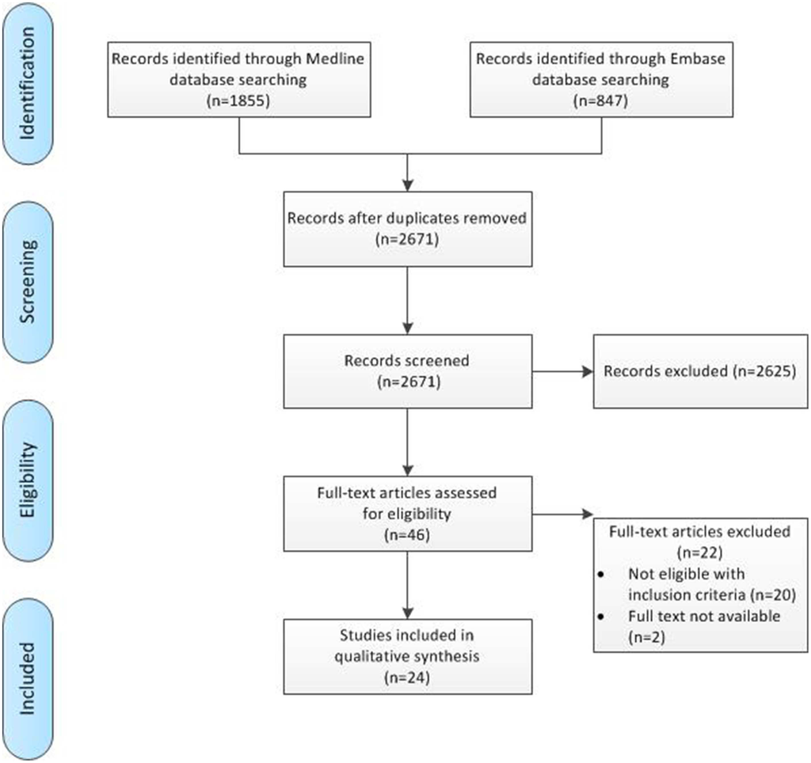

FIGURE 1 | Flowchart of pre-clinical search process.

acids), ﬁve studies evaluated lipids, three studies evaluated

probiotics, two studies evaluated prebiotics, one study evaluated

minerals and one study evaluated vitamins. There were no

studies that evaluated only carbohydrate intake. The clinical

characteristics of the included studies are summarized in **Table 2**.

Protein Intake (Including Individual Amino

Acids)

Pre-clinical Trials

The eﬀects of protein or amino acid supplementation on

neonatal brain injury were described in eight pre-clinical

studies. Of those studies, two studies investigated the eﬀects

of supplementation with lactoferrin (van de Looij et al., 2014;

Ginet et al., 2016), a protein abundantly present in human milk.

Furthermore, three studies were focused on amino acid-based

biosynthetic products acetyl-l-carnitine (Xu et al., 2015; Tang

et al., 2016) and taurine (Zhu et al., 2016) that are also present in

human milk. Additionally, three pre-clinical studies focused on

supplementation with the single amino acids glycine (Mori et al.,

2017) or L-cysteine (Liu et al., 2017; Xin et al., 2018).

Lactoferrin is a glycoprotein produced by exocrine glands

and released at high levels in human milk, especially colostrum

(Nagasawa et al., 1972). van de Looij et al. (2014) investigated

the eﬀects of maternal lactoferrin supplementation in a rat model

of preterm hypoxic-ischemic encephalopathy (HIE), induced at

post-natal day 3 (P3, equivalent to 24–28 weeks gestational age

in humans) that presents with impaired cortical development

and white matter integrity (van de Looij et al., 2014). Lactoferrin

(1 g/kg/day) was supplemented in the maternal diet from

P0 throughout lactation and resulted in increased levels of

lactoferrin in the stomach and serum of the oﬀspring. MRI

analysis revealed reduced cerebral edema hours after the insult

and reduced cortical loss accompanied by improved diﬀusivity at

post-natal day 25 in neonatal rats supplemented with lactoferrin.

Also the impairments in white matter structure were partly

restored upon lactoferrin supplementation, as indicated by

improved diﬀusivity and FA values in the external capsule but

not in the corpus callosum of injured rats supplemented with

lactoferrin compared to control diet. The authors hypothesized

that neuroprotective eﬀects of lactoferrin may be driven by

its anti-inﬂammatory properties, as indicated by a reduction

of brain TNF-α and IL-6 expression, which resulted in

reduced apoptotic cell death, as indicated by reduced caspase 3

activation at 1 day after injury in the lactoferrin-supplemented

rats compared to controls. In a following study, the same

research group repeated the lactoferrin intervention study in

an inﬂammation-induced rat model of preterm brain injury,

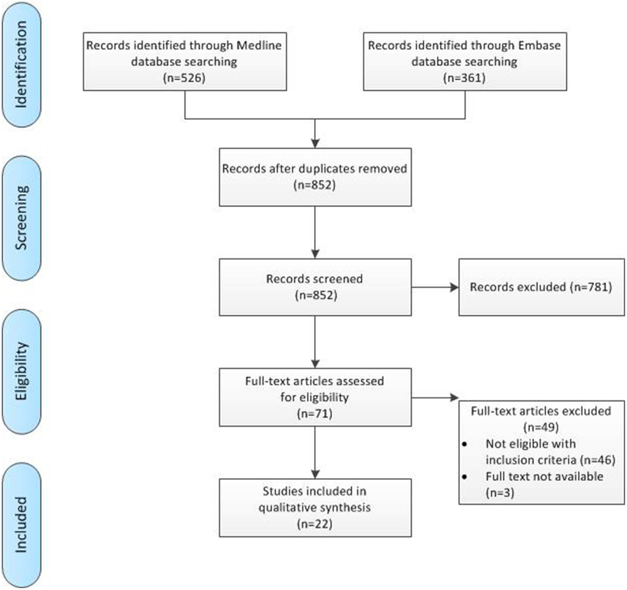

FIGURE 2 | Flowchart of clinical search process.

using injection of LPS in the subcortical white matter at

P3 (Ginet et al., 2016). Lactoferrin supplementation during

lactation again provided neuroprotection as shown by reduced

ventriculomegaly, lesion size, and myelination deﬁcits. Although

lactoferrin supplementation did not reduce astrogliosis and

pro-inﬂammatory cytokine expression, it did reduce microglia

activation as compared to the control diet in the LPS-injured

neonatal rat brain.

The

biosynthetic

product

acetyl-l-carnitine

is

also

brain and its metabolite carnitine facilitates long chain fatty acid

metabolism to produce energy. One group described in two

studies the eﬀects of acetyl-l-carnitine supplementation in a rat

model of neonatal HIE induced at P7 (equivalent to near term in

humans) (Xu et al., 2015; Tang et al., 2016). Pups were injected

subcutaneously with 4 doses of 100 mg/kg acetyl-l-carnitine at

0, 4, 24, and 48 h post-HI. Treatment with acetyl-l-carnitine

reduced lesion size and promoted oxidative cerebral energy

production and minimized anaerobic glycolysis, if administered

early after the HI insult (Xu et al., 2015). In the second study,

acetyl-l-carnitine supplementation again reduced lesion size,

and also improved simple reﬂexes and spatial memory but not

social play, when compared to HIE rats that received vehicle

(Tang et al., 2016).

Although strictly classiﬁed as a biosynthetic compound

derived from cysteine and methionine, taurine is often regarded

as the second most abundant amino acid in human milk (Rassin,

1981). After consumption, taurine accumulates in the brain

in high concentrations (Rassin, 1981), where it has various

functions, for example as a neurotransmitter and trophic factor

(Wu and Prentice, 2010). One pre-clinical trial investigated the

eﬀects of taurine supplementation in a rat model of neonatal

HIE induced at P7 (Zhu et al., 2016). Taurine was administered

intraperitoneally (i.p.) every 12 h for 2 days post-HI at doses of

30–120 mg/kg. Taurine dose-dependently reduced lesion size, cell

death, and oxidative stress in brains of neonatal HIE rats, as

compared to vehicle.

In summary, supplementation with lactoferrin from the day

of birth was neuroprotective in two models of preterm brain

injury, as shown by improvement of neurological outcome

on MRI, potentially though inhibition of neuroinﬂammation.

In addition, peripheral administration of amino acid-based

biosynthetic products acetyl-l-carnitine and taurine after the

insult, reduced lesion size in a rat model of neonatal near

term HIE.

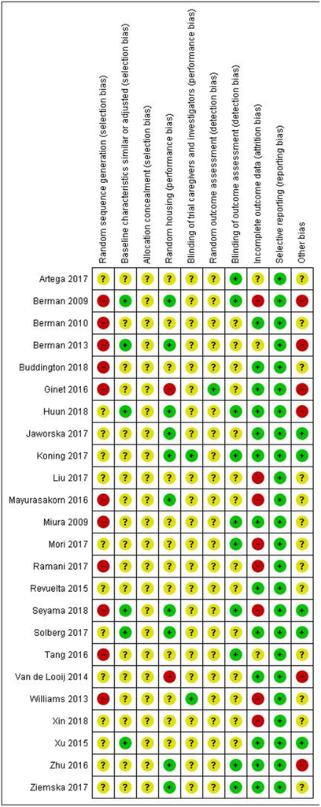

FIGURE 3 | Risk of bias of individual pre-clinical studies.

The amino acid glycine acts as an important inhibitory

neurotransmitter in the brain. The eﬀects of glycine treatment

were described in one study in a rat model of neonatal HIE

induced at P7 (Mori et al., 2017). Intraperitoneal injections with

800 mg/kg glycine prior to the hypoxic insult induced a large

but brief increase in glycine concentrations in the cerebrospinal

ﬂuid and subsequently reduced lesion size and neuronal cell

death in neonatal HIE rats, when compared to vehicle injections.

This neuroprotection by glycine was associated with reduced

expression of TNF-α levels at 12 and 24 h post-HI and 3 days later,

reduced neuroinﬂammation was measured by a lower numbers of

astrocytes and microglia in the lesioned area.

One group reported in two pre-clinical studies the eﬀects

of l-cysteine treatment in a mouse model of neonatal HIE

induced at P7 (Liu et al., 2017; Xin et al., 2018). L-cysteine

is catalyzed in the brain to produce endogenous hydrogen

sulﬁde (H2S), which has been suggested to inhibit inﬂammation,

oxidative stress and apoptosis. Neonatal mice were subjected to

HI and given daily intraperitoneal injections with 2.5–5.0 mg/kg

l-cysteine for 3 consecutive days, starting immediately post-HI.

Treatment with l-cysteine attenuated brain edema, lesion size

and neuronal cell death after neonatal HIE, when compared to

vehicle (Liu et al., 2017; Xin et al., 2018). L-cysteine treatment

also improved behavioral deﬁcits, including neurological reﬂexes

and spatial working memory, in mice with neonatal HIE. The

neuroprotective eﬀects of l-cysteine on functional and anatomical

outcome in neonatal mice with HIE were associated with

improved synapse formation and reduced oxidative stress and

neuroinﬂammation, as measured by microglia and astrocyte

inﬁltration. Furthermore, the treatment eﬀect of l-cysteine was

reversed when H2S formation was inhibited in vivo, indicating

that the neuroprotective mechanisms of l-cysteine depend on its

function as an H2S donor.

In summary, single amino acid supplementations with glycine

(as a pre-treatment) and l-cysteine (as a post-treatment) in

rodent models of neonatal near term HIE reduced brain injury

and neuroinﬂammation, and the latter treatment also improved

behavioral outcome.

Clinical Trials

Ten randomized controlled clinical trials (RCTs) described

outcome after amino acid or protein supplementation (Amin

et al., 2009; Blanco et al., 2012; de Kieviet et al., 2012, 2014;

Burattini et al., 2013; van den Akker et al., 2014; Bellagamba

et al., 2016; Balakrishnan et al., 2017; Dogra et al., 2017; Twilhaar

et al., 2018a). In six trials diﬀerent quantities of amino acids

or protein were evaluated, but all trials had diﬀerent target

values for intervention or control group, diﬀerent starting time

of intervention and/or diﬀerent length of intervention. Three

studies (Blanco et al., 2012; Burattini et al., 2013; Balakrishnan

et al., 2017) evaluated increased parenteral supplementation with

amino acids, starting shortly after birth and targeting 4 g/kg/day

within the ﬁrst days of life, compared to control, aiming on 2,

2.5, or 3 g/kg/day within the ﬁrst days of life. In total, these

studies evaluated 242 infants around 18–24 months corrected

age. No beneﬁcial eﬀect of high dose of parenteral amino acid

supplementation on neurodevelopment was found. Burattini

et al. (2013) found no diﬀerence in neurodevelopmental outcome

or growth between the two groups (n = 96 in total). Balakrishnan

et al. (2017) found no diﬀerence in neurodevelopmental outcome

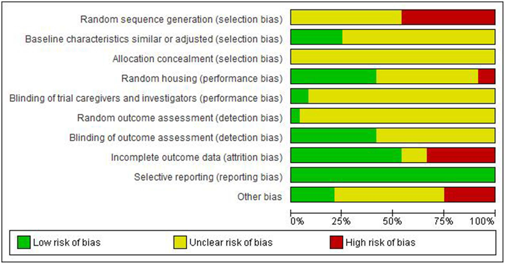

FIGURE 4 | Risk of bias across pre-clinical studies.

(n = 114 in total), but did ﬁnd lower mean weight, length and

head circumference at discharge in infants that received high

amino acid supplementation. Blanco et al. (2012) found that

infants in the intervention group had signiﬁcantly lower Mental

Developmental Index (Bayley Scales of Infant and Toddler

Development, second edition) at 18 months corrected age. At 24

months follow up, this diﬀerence was no longer present and no

other diﬀerences in neurodevelopmental outcome between the

two groups were observed (n = 32 in total). However, during

the 24 months follow up period, infants in the intervention

group showed signiﬁcantly lower head circumference and overall

growth. One study evaluated a diﬀerent target level of amino

acids. Bellagamba et al. (2016) evaluated enriched (3.5 g/kg/day

parenteral and 4.6 g/kg/day enteral) vs. regular (2.5 g/kg/day

parenteral and 3.6 g/kg/day enteral) supplementation from day

of birth until a weight of 1,800 g was achieved. The intervention

included both parenteral and enteral supplementation. At 2 years

corrected age, no diﬀerence in neurodevelopmental outcome was

seen (n = 164 in total). One study assessed the eﬀect of early

amino acid supplementation during the ﬁrst 3 days of life. van

den Akker et al. (2014) started parenteral supplementation (2.4

g/kg/day) within 2 h after birth in comparison to controls, who

started 24–48 h after birth (1.2 g/kg/day, increased to 2.4 g/kg/day

on day 3). At 2 years of age, no diﬀerence in outcome between

both groups was seen (n = 111 in total). However, subgroup

analysis revealed higher odds of normal outcome for boys treated

with early amino acids (OR 6.17 [1.01–38.46]). In contrast,

girls in the intervention group had a signiﬁcantly lower Mental

Developmental Index compared to girls in the control group.

The paper by Dogra et al. (2017) was the only study evaluating

exclusive enteral protein supplementation. Infant feedings were

supplemented with regular (0.4 g/100 ml) or protein enriched

(1.0 g/100 ml) HMF, which started at an enteral feeding volume

of 100 ml/kg/day and ended at discharge. At term equivalent

age, infants that received protein enriched HMF had signiﬁcantly

greater head circumferences. However, during the 2 year follow

up period, no diﬀerence in growth nor mental or motor outcome

was seen (n = 92 in total).

In summary, all studies combined investigated 609 infants

and conﬂicting evidence was found. Most studies found no

improvement of neurodevelopmental outcome after early and/or

enriched (par)enteral amino acid supplementation or found an

adverse eﬀect on growth and head circumference. The single

study that described exclusive enteral protein supplementation

showed a beneﬁcial eﬀect on head circumference, but not on

neurodevelopmental outcome.

Supplementation with a single amino acid was described

in four papers. de Kieviet et al. (2012, 2014) and Twilhaar

et al. (2018a) described in three papers long term follow up

after the same RCT (GEEF study), investigating glutamine

supplementation (de Kieviet et al., 2012, 2014; Twilhaar et al.,

2018a). Infants received enteral glutamine supplementation (0.3

g/kg/day) or placebo between post-natal day 3 and day 30. The

eﬀect of glutamine on head circumference growth during the ﬁrst

year of life (n = 65 in total) (de Kieviet et al., 2014) and brain

volumes at 8 years of age (n = 52 in total) (de Kieviet et al.,

2012) was evaluated. Glutamine supplementation was associated

with increased head circumference growth during the ﬁrst year

of life as well as with increased white matter, hippocampal and

brain stem volumes at 8 years. Neurodevelopmental follow up at

13 years of age (n = 61 in total) showed comparable outcomes

on all domains between glutamine and placebo groups, except

for the visuospatial working memory forward span and the

parent rated attention skills, which favored the control group

(Twilhaar et al., 2018a).

In a diﬀerent study, Amin et al. (2009) evaluated the eﬀect of

261 mg/kg/day L-arginine compared to placebo during the ﬁrst

28 days of life on neurodevelopmental outcome at 36 months

corrected age (n = 132 in total). No signiﬁcant diﬀerence was

found in neurodevelopmental outcome between both groups.

In summary, enteral glutamine supplementation showed

increased head circumference growth during the ﬁrst year of

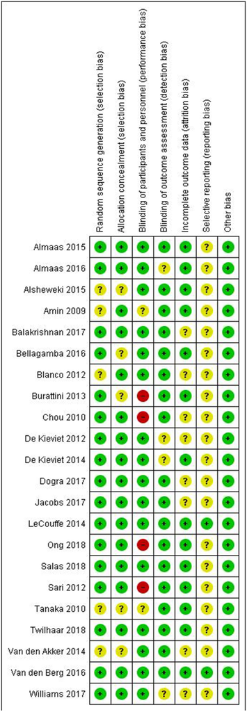

FIGURE 5 | Risk of bias of individual clinical studies.

life and increased brain volumes at 8 years. However, at 13

years of age, no positive eﬀect of glutamine was found on

neurodevelopmental outcome. Working memory and attention

skills diﬀered between the glutamine and control group, favoring

the control group, but were within the normal range for

both groups.

No

advantage

from

supplementation

with

L-arginine

was detected.

Lipid Intake (Including Fatty Acids)

Pre-clinical Trials

The eﬀects of lipid supplementation on pre-clinical neonatal

brain injury have been reported in 10 studies, all focused on

docosahexaenoic acid (DHA) supplementation only (Berman

et al., 2009, 2010, 2013; Williams et al., 2013; Mayurasakorn et al.,

2016; Revuelta et al., 2016; Arteaga et al., 2017; Solberg et al., 2017;

Buddington et al., 2018; Huun et al., 2018).

In a rat model for neonatal HIE induced at P7, an i.p. injection

of 1–5 mg/kg DHA 4 h prior to the insult improved sensorimotor

outcome and reduced lesion size (Berman et al., 2009). In a

similar neonatal HIE model, 1 mg/kg DHA was administered i.p.

at 10 min prior the HI insult, and prevented impairments in the

auditory brain stem response and in myelination of the inferior

colliculus, a principal midbrain nucleus of the auditory pathway

(Revuelta et al., 2016). Neuron morphology and astrogliosis was

also measured, but not statistically analyzed. In addition, the

group reported in a similar experimental design that DHA pre-

treatment reduced lesion size and mitochondrial cell damage

at the hippocampal level, and rescued deﬁcits in myelination

in the external capsule and striatum and in spatial memory

(Arteaga et al., 2017). In a rat model for neonatal inﬂammatory

HIE using LPS injection prior to HI, pre-treatment with DHA

improved sensorimotor outcome, but did not reduce lesion size

(Berman et al., 2010).

In addition to DHA administration prior to the insult, also

treatment after the insult has been investigated in rodent models

of neonatal HIE. Williams et al. (2013) compared post-treatment

with DHA or eicosapentaenoic acid (EPA) triglycerides in a

mouse model for neonatal HIE induced at P10 (equivalent to near

term in humans) (Williams et al., 2013). Triglyceride emulsions

allow for slower release of n-3 fatty acids and therefore avoid high

levels of n-3 fatty acids that may lead to brain and liver toxicity

(Singh et al., 1989; Oliveira et al., 1997). Intraperitoneal treatment

with 375 mg/kg of tri-DHA, but not tri-EPA, immediately after

the HI insult reduced lesion size. Furthermore, a treatment

delay for up to 2 h after the insult provided neuroprotection on

histology level, but a further delay failed to reduce lesion size. In a

subsequent study, the group demonstrated that neuroprotection

by tri-DHA after neonatal HIE was associated with increased

DHA content in the mitochondria and DHA-derived bioactive

metabolites in the brain (Mayurasakorn et al., 2016). Tri-DHA

treatment immediately post-HI reduced oxidative damage in the

brain and improved long-term neurological outcomes. Also in

combination with hypothermia, DHA supplementation reduced

lesion size and improved sensorimotor outcome when compared

to treatment with hypothermia only (Berman et al., 2013).

To improve clinical translation of DHA therapy for neonatal

brain injury, Solberg et al. (2017) investigated the eﬀects

of DHA in a newborn piglet model of severe hypoxia-

reoxygenation (Solberg et al., 2017). DHA was administered

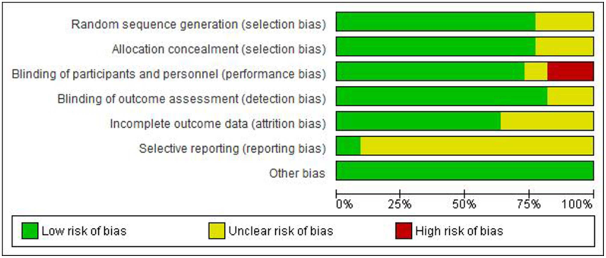

FIGURE 6 | Risk of bias across clinical studies.

i.v. at 5 mg/kg in newborn piglets at 4 h after subjection to

hypoxia. Lipid peroxidation markers were signiﬁcantly lower in

the hippocampus and cortex of DHA-treated newborn piglets

compared to the untreated control group measured at 9.5 h after

treatment. These results indicate that DHA has anti-oxidative

eﬀects in the brain. Additionally, the group recently reported

in a similar experimental design changes in oxidative stress

in diﬀerent brain regions in response to DHA in combination

with hypothermia (Huun et al., 2018). In the white matter,

regardless of hypothermia treatment, DHA reduced the levels of

di-homo-isoprostanes, a product of adrenic acid oxidation. In the

cortex, DHA signiﬁcantly reduced levels of neurofuranes and di-

homo-isoprostanes, only when hypothermia was not applied. In

contrast to the ﬁrst study of Solberg et al. (2017), no diﬀerences

were observed in the hippocampus.

In addition, one study reported the eﬀects of oral DHA

supplementation in preterm-born piglets at 92% gestation

(considered relevant to 32 week-old preterm infant) (Buddington

et al., 2018). Preterm pigs were born by sterile caesarian

section and provided with parenteral nutrition for 16–18 h.

Thereafter, the source of nutrition was entirely milk replacer.

Milk replacer was supplemented with phosphotidylserine (PS)–

DHA to provide 58 mg/kg/day, or sunﬂower oil as the placebo.

Based on rat experiments (Vaisman and Pelled, 2009), the

authors argue that chronic administration of PS-DHA results

in greater DHA accretion in the cortex compared with tri-

DHA, indicating further improved DHA bioavailability. PS-

DHA was supplemented until euthanization at term-equivalent

age, i.e., 10 days after delivery. Supplementing preterm pigs

with PS-DHA did not increase overall weight gain, but did

signiﬁcantly restore the decline in weight of the cerebellum

at term-equivalent age up to the weight of term control

pigs. PS-DHA supplementation also resulted in higher DTI

indices in diﬀerent brain regions, including the internal capsule,

thalamus, hypothalamus, globus pallidus, hippocampus, and

cortex. This indicates that a higher degree of myelination was

present in brains of preterm pigs that were supplemented

with PS-DHA as compared to placebo. Additionally, PS-

DHA supplementation accelerated development of recognition

memory and the auditory pathway as compared with placebo-

treated preterm piglets.

In summary, these pre-clinical studies demonstrate that

peripheral DHA supplementation eﬀectively reduced lesion size

and improved neurodevelopmental outcome in rodent models of

neonatal HIE, when administered prior to of soon after the insult.

In addition, DHA supplementation reduced lipid peroxidation

markers in a piglet model of severe hypoxia-reoxygenation,

indicating that DHA has anti-oxidative eﬀects in the brain.

In preterm-born piglets, enteral supplementation with DHA

improved white matter integrity and cerebellar growth.

Clinical Trials

In total, ﬁve trials that described outcome after an intervention

with lipids were included. Of those, one trial evaluated the eﬀect

of diﬀerent amounts of lipids (Ong et al., 2018), three trials

focused on supplementation with fatty acids (Almaas et al., 2015,

2016; Alshweki et al., 2015), and in one trial supplementation

with sphingomyelin was used (Tanaka et al., 2013).

Ong et al. (2018) described the only included study in which

diﬀerent quantities of regular parenteral lipids were studied.

They explored the impact of low (1 g/kg/day) and standard

(3 g/kg/day) dose parenteral lipids (soybean oil, Intralipid) on

growth and neurodevelopmental outcome until 2 years corrected

age. No diﬀerence was found in neurodevelopmental outcome

or growth up to 2 years of age between the groups (n = 30 in

total) that received low or high dose soybean, with an exception

for 12 months corrected age, at which a signiﬁcant higher

cognitive composite score was found in the patients with low dose

soybean oil.

Supplementation with the fatty acids DHA and arachidonic

acid (AA) was investigated in three included studies. In two

papers, Almaas et al. (2015, 2016) described (1) cognitive (n =

98 in total) and brain volume outcome (Almaas et al., 2015)

(n = 81 in total), and (2) Diﬀusion Tensor Imaging (n = 82

in total), and behavioral outcome (Almaas et al., 2016) (n =

98 in total) at 8 years of age in infants supplemented with

enteral DHA and AA (ratio 1/1). Supplementation was initiated

when the infant reached enteral feeding of 100 ml/kg/day and

TABLE 1 | Baseline characteristics of included pre-clinical studies.

Study

Nutritional

component

Timing (and mode) of administration

Brain injury model

Primary outcome measure

van de Looij et al., 2014

Lactoferrin

Pre- and post-treatment (enteral, in

maternal diet)

HI P3 rat

Lesion size, myelination

Ginet et al., 2016

Lactoferrin

Pre- and post-treatment (enteral, in

maternal diet)

LPS i.c. P3 rat

Lesion size, myelination

Xu et al., 2015

Acetyl-l-carnitine

Post-treatment (s.c.)

HI P7 rat

Lesion size

Tang et al., 2016

Acetyl-l-carnitine

Post-treatment (s.c.)

HI P7 rat

Lesion size, behavior

Zhu et al., 2016

Taurine

Post-treatment (i.p.)

HI P7 rat

Lesion size

Mori et al., 2017

Glycine

Pre-treatment (i.p.)

HI P7 rat

Lesion size

Liu et al., 2017

L-cysteine

Post-treatment (i.p.)

HI P7 mouse

Lesion size, behavior

Xin et al., 2018

L-cysteine

Post-treatment (i.p.)

HI P7 mouse

Lesion size, behavior

Berman et al., 2009

DHA

Pre-treatment (i.p.)

HI P7 rat

Lesion size, behavior

Revuelta et al., 2016

DHA

Pre-treatment (i.p.)

HI P7 rat

Myelination

Arteaga et al., 2017

DHA

Pre-treatment (i.p.)

HI P7 rat

Lesion size, myelination,

behavior

Berman et al., 2010

DHA

Pre-treatment (i.p.)

HI+ LPS P7 rat

Lesion size, behavior

Williams et al., 2013

tri-DHA tri-EPA

Post-treatment (i.p.)

HI P10 mouse

Lesion size

Mayurasakorn et al., 2016

tri-DHA tri-EPA

Post-treatment (i.p.)

HI P10 mouse

Lesion size, behavior

Berman et al., 2013

DHA

Post-treatment (i.p.)

HI P7 rat

Lesion size, behavior

Solberg et al., 2017

DHA

Post-treatment (i.v.)

HR newborn piglet

Lipid peroxidation

Huun et al., 2018

DHA

Post-treatment (i.v.)

HR newborn piglet

Lipid peroxidation

Buddington et al., 2018

PS-DHA

Post-treatment (enteral)

Preterm-born piglet

Brain weight, myelination

Jaworska et al., 2017

Na-butyrate

Post-treatment (i.p.)

HI P7 rat

Lesion size

Ziemka-Nalecz et al., 2017

Na-butyrate

Post-treatment (i.p.)

HI P7 rat

Behavior

Ramani et al., 2017

Vitamin A

Post-treatment (enteral)

Hyperoxia P2–14 mouse

Behavior

Miura et al., 2009

Vitamin C

Pre-treatment (i.p.)

HI P7 rat

Macroscopical lesion size

Koning et al., 2017

MgSO4

Pre-treatment (i.p.)

HI P7 rat

Lesion size

Seyama et al., 2018

MgSO4

Pre-treatment (i.p.)

HI P6 rat

Myelination

i.p., intraperitoneal; i.v., intravenous; s.c., subcutaneous; i.c., intracranial; HI, hypoxia-ischemia; HR, hypoxia-reoxygenation; P, postnatal day; DHA, docosahexaenoic acid;

EPA, eicosapentaenoic acid; tri, triglyceride; PS, phosphatidylserine; Na, sodium; MgSO4, magnesiumsulphate.

consisted of 0.5 ml study oil on 100 ml milk, which contained

32 mg DHA and 31 mg AA or placebo. Intervention ended

when the patient was discharged or when a total of 100 ml

of study oil was given. At 8 years of age outcome on brain

volumes, cortical volumes, surface areas, thickness and white

matter tract development as well as cognitive and motor outcome

was similar between the fatty acid-supplemented and placebo

patients. Alshweki et al. (2015) investigated the eﬀect of AA/DHA

ratio on outcome. They provided infants with enriched AA

formula (AA/DHA ratio 2/1) or regular formula (ratio 1/1) and

attempted to maintain this ratio in infant feeding during the

entire follow up period of 2 years (n = 45 in total). A group

of 25 infants that received exclusively breast milk were used

as control group. At 2 years of age, the infants that received

enriched AA formula had a higher score on the Brunet Lézine

scale (Scale of Psychomotor Development of Children) compared

to infants that received standard infant formula. Additionally,

compared to breastfed controls, AA-enriched formula infants

had similar Brunet Lézine scales whereas regular formula infants

had signiﬁcantly lower scores.

Tanaka et al. (2013) focused on supplementation with

sphingomyelin. Infants (n = 24 in total) received either

sphingomyelin-fortiﬁed enteral feeding (sphingomyelin 20%

of all phospholipids in milk) or standard enteral feeding

(sphingomyelin 13% of all phospholipids in milk). At 3–18

months of age infants in the intervention group scored better on

the preference rate on the Fagan test and the sustained-attention

test and showed shorter latency of visual evoked potentials. No

diﬀerences in mental or psychomotor development were found.

In summary, in the one study that we included on

quantities of lipids, no diﬀerence between high and low

dose soybean oil was found at 2 years of age (n = 30 in

total). DHA and AA supplementation showed no eﬀect on

brain volumes, brain maturation, and neurodevelopmental

outcome (n = 98 in total). High AA/DHA ratio (2/1) did

show a positive eﬀect on Brunet Lézine scale compared to

regular AA/DHA ratio (1/1) (n = 45 in total). Sphingomyelin

supplementation

improved

some

neurodevelopmental

outcome measures, but showed no eﬀect on mental or

psychomotor development.

Frontiers in Physiology | www.frontiersin.org

11

July 2019 | Volume 10 | Article 961

Hortensius et al.

Nutrition to Improve Brain Development

TABLE 2 | Baseline characteristics of included clinical studies.

Study

Nutritional

component

Enteral/parenteral Inclusion criteria

Selected

infants (n)

Primary study

outcome

NDO or brain injury

outcome measure

Blanco et al., 2012

Protein

Parenteral

>24 weeks and <1,000 g

32

Reduction of potassium NDO 0–24 months

Burattini et al., 2013

Protein

Parenteral

<1,250 g

96

Body seize at 36 weeks

PMA

NDO 24 months

Balakrishnan et al., 2017

Protein

Parenteral

<32 weeks and <1,250 g

114

NDO 18–24 months

NDO 18–24 months

van den Akker et al., 2014

Protein

Parenteral

<32 weeks and <1,500 g

111

Short term safety and

efﬁcacy

NDO 24 months

Bellagamba et al., 2016

Protein

Both

<1,250 g

164

Weight gain from

birth−1,800 g

NDO 24 months

Dogra et al., 2017

Protein

Enteral

<32 weeks or <1,500 g

92

Head growth at 40

weeks PMA

NDO 12–18 months

de Kieviet et al., 2012

Glutamine

Enteral

<32 weeks or <1,500 g

65

Feeding tolerance

Brain volumes and white

matter integrity at 8 years

de Kieviet et al., 2014

Glutamine

Enteral

<32 weeks or <1,500 g

52

Feeding tolerance

HC growth at 1 year and

brain volumes at 8 years

Twilhaar et al., 2018a

Glutamine

Enteral

<32 weeks or <1,500 g

61

Feeding tolerance

NDO 13 years

Amin et al., 2009

L-arginine

Both

≤32 weeks or ≤1,250 g

132

Necrotizing enterocolitis NDO 36 months

Ong et al., 2018

Lipids

Parenteral

≤29 weeks

30

Cholestasis

NDO 6–24 months

Almaas et al., 2015

DHA, AA

Enteral

<1,500 g

98

NDO 6 months

NDO, brain volumes and

brain maturation at 8 years

Almaas et al., 2016

DHA, AA

Enteral

<1,500 g

98

NDO 6 months

Behavior and white matter

integrity at 8 years

Alshweki et al., 2015

AA/DHA ratio

Enteral

25–32 weeks or <1,500 g

45

NDO 24 months

NDO 24 months

Tanaka et al., 2013

Sphingomyelin

Enteral

<1,500 g

24

NDO 0–18 months

NDO 0–18 months

Chou et al., 2010

Probiotics

Enteral

<1,500 g

301

Necrotizing enterocolitis NDO 3 years

Jacobs et al., 2017

Probiotics

Enteral

<32 weeks and <1,500 g

735

Late onset sepsis

NDO 2–5 years

Sari et al., 2012

Probiotics

Enteral

<33 weeks or <1,500 g

174

Necrotizing enterocolitis NDO 18–22 months

LeCouffe et al., 2014

Prebiotics

Enteral

<32 weeks or <1,500 g

93

Neonatal infections

NDO 0–12 months

van den Berg et al., 2016

Prebiotics

Enteral

<32 weeks or <1,500 g

77

Neonatal infections

NDO 24 months

Salas et al., 2018

Vitamin D

Enteral

23–27 weeks

91

Vitamin D concentration NDO 22–26 months

Williams et al., 2017

Iodide

Both

<31 weeks

1,259

NDO 24 months

NDO 24 months

NDO, Neurodevelopmental outcome; PMA, Postmenstrual age; HC, Head circumference; DHA, Docosahexaenoic acid; AA, Arachidonic acid.

Probiotic Supplementation

Pre-clinical Trials

Although no pre-clinical studies were found on the use

of probiotics to improve neurodevelopmental outcome after

neonatal brain injury, one group investigated the eﬀects of

butyrate (Jaworska et al., 2017; Ziemka-Nalecz et al., 2017),

a short-chain fatty acid synthesized by bacteria in the colon

by fermenting otherwise non-digestible ﬁber. Butyrate enters

the bloodstream and subsequently the brain where it serves as

a histone deacetylase (HDAC) inhibitor, activates G protein-

coupled receptors, and acts as an energy metabolite to produce

ATP. In two publications, the authors demonstrated in rats

with neonatal HIE induced at P7 that i.p administration of 300

mg/kg sodium butyrate for ﬁve consecutive days post-HI reduced

lesion size and neuroinﬂammation, as measured by levels of

IL-1β and chemokine CXCL10 and polarization of microglia

from pro-inﬂammatory M1 to anti-inﬂammatory M2 (Jaworska

et al., 2017; Ziemka-Nalecz et al., 2017). In addition, butyrate

treatment enhanced the generation of newly formed neuroblasts

and oligodendrocytes in the dentate gyrus of the hippocampus

of neonatal HIE rats, as compared to vehicle treatment. This

neuroregenerative eﬀect of butyrate is potentially driven by

enhanced endogenous production of BDNF in the ipsilateral

hemisphere. However, butyrate treatment failed to improve

neurobehavioral outcome, as measured by behavioral tasks for

motor function, spatial memory and social communication.

Clinical Trials

Three trials were included that used diﬀerent (combinations of)

bacteria as probiotic supplementation (Chou et al., 2010; Sari

et al., 2012; Jacobs et al., 2017). Chou et al. (2010) supplemented

preterm infants (n = 301 in total) with Inﬂoran, containing

Lactobacillus acidophilus and Biﬁdobacterium infantis, or placebo

from 1 week after birth until discharge. Follow up at 3 years

showed no diﬀerence in neurodevelopmental outcome between

both groups. Jacobs et al. (2017) included and randomized

patients (n = 735 in total) in receiving a combination

of Biﬁdobacterium infantis, Streptococcus thermophiles, and

Biﬁdobacterium lactis or placebo, from 72 h after birth until

discharge or term equivalent age. Outcome was assessed

Frontiers in Physiology | www.frontiersin.org

12

July 2019 | Volume 10 | Article 961

Hortensius et al.

Nutrition to Improve Brain Development

between 2 and 5 years of age and no diﬀerence was

found between both groups. Sari et al. (2012) evaluated the

eﬀect of supplementation of all feedings until discharge with

Lactobacillus Sporogenus on neurodevelopmental outcome at

18–22 months corrected age (n = 174 in total). Again, no

eﬀect of supplementation on neurodevelopmental outcome

was observed.

In total, all three studies combined evaluated 1,210 patients. In

none of the studies, a signiﬁcant eﬀect of supplementation with

probiotics on neurodevelopmental outcome was found.

Prebiotic Supplementation

Pre-clinical Trials

No pre-clinical studies were found on prebiotic supplementation

for the treatment of neonatal brain injury.

Clinical Trials

Two papers described neurodevelopmental outcome after

supplementation with prebiotics (LeCouﬀe et al., 2014; van

den Berg et al., 2016). Both papers assessed the same cohort,

but at diﬀerent time points. LeCouﬀe et al. (2014) evaluated

outcome in the ﬁrst year of life (n = 93 in total), whereas

van den Berg et al. (2016) described outcome at 2 years

corrected age (n = 77 in total). Intervention consisted of

small-chain

galacto-oligosaccharides

(scGOS),

long-chain

fructo-oligosaccharides

(lcFOS)

and

pectin-derived

acidic

oligosaccharides (pAOS) compared to controls from day 3 until

day 30 post-natal. During the entire follow up period of 2 years,

no signiﬁcant diﬀerence was found in neurodevelopmental

outcome

between

the

patients

with

and

without

prebiotics supplementation.

Vitamin Intake

Pre-clinical Trials

The eﬀects of vitamins on neonatal brain injury were described in

two pre-clinical studies (Miura et al., 2009; Ramani et al., 2017).

The ﬁrst study investigated whether a combination of vitamin

A and its derivate retinoic acid attenuated hyperoxia-induced

preterm brain injury in mice (Ramani et al., 2017). Chronic

hyperoxia from P2–14 (equivalent to 24–40 weeks gestational age

in humans) induced deﬁcits in spatial memory and reductions in

hippocampal volume and hippocampal synaptophysins. Enteral

treatment with vitamin A (0.05 mmol/g) and retinoic acid (0.005

mmol/g) every other day during the hyperoxic period partially

restored brain injury and behavioral outcome in mice subjected

to hyperoxia. The authors suggested that neuroprotection by

vitamin A plus retinoic acid was mediated via increased signaling

of the mTOR pathway.

In the second study, the eﬀect of vitamin C (i.e., ascorbic

acid) was tested in a rat model of neonatal HIE induced at P7

(Miura et al., 2009). Treatment with 750 mg/kg of vitamin C

i.p. prior to hypoxia reduced macroscopical brain injury and

apoptotic and necrotic cell death in the cortex, hippocampus,

caudate putamen, and thalamus of rats with neonatal HIE, as

compared to vehicle. Microscopical analysis of lesion size was not

examined in this study.

Clinical Trials

Only one RCT evaluated the eﬀect of vitamin supplementation

on neurodevelopmental outcome. Salas et al. (2018) studied

the impact of two diﬀerent doses of vitamin D (200 or 600

IU/day) compared to placebo from day 1 of enteral feeding until

day 28 post-natal on neurodevelopmental outcome at 2 years

of age (n = 91 in total). They found no signiﬁcant diﬀerence

in neurodevelopmental impairment (including cerebral palsy),

cognitive impairment and language impairment between patients

in the placebo group, the low dose supplementation group or the

high dose supplementation group.

Mineral Intake

Pre-clinical Trials

The eﬀects of magnesium sulfate (MgSO4) supplementation

were described in two pre-clinical studies from the same

group (Koning et al., 2017; Seyama et al., 2018), using a rat

model of neonatal HIE induced at P6 or P7. The ﬁrst study

in P7 rats demonstrated that the optimal dose of 1.1 mg/g

MgSO4 i.p. eﬀectively reduced lesion size when given as a

pre-treatment between 6 days and 12 h prior to the insult,

but not at later timepoints (Koning et al., 2017). In addition,

mRNAs and miRNAs involved in metabolism and mitochondrial

function were altered and mitochondrial respiration was

preserved upon MgSO4 supplementation of neonatal HIE rats.

MgSO4 pretreatment attenuated HI-induced increases in ROS

production and neuroinﬂammation, as measured by cytokines

and chemokine levels. The second study investigated MgSO4

pretreatment in a neonatal HIE rat model induced at P6

(equivalent to 29 weeks gestational age in humans) (Seyama et al.,

2018). HI at this age generates selective decrease in myelination

in the pericallosal white matter without overt gray matter loss,

which more closely resembles non-cystic PVL. Pretreatment

with MgSO4, 30 min before the hypoxic insult, attenuated

hypomyelination of the ipsilateral pericallosal white matter, as

compared to vehicle pre-treatment. This increase in myelination

was associated with increased oligodendrocyte numbers in vivo

and reduced pre-oligodendrocyte death in vitro. Therefore, the

authors suggested that MgSO4 ameliorated the white matter

damage by preventing cell death of pre-oligodendrocytes.

Clinical Trials

Williams et al. (2017) investigated neurodevelopmental outcome

after iodide supplementation. Preterm infants (n = 1259 in total)

were randomly assigned to receive either placebo (30 µg/kg/day

sodium chloride) or iodide supplementation (30 µg/kg/day

sodium iodide) from <42 h after birth until 34 weeks gestational

age. Neurodevelopmental outcome at 2 years of age was not

signiﬁcantly diﬀerent in the groups.

DISCUSSION

With this review we provided an overview of the currently

available evidence for the eﬀect of nutritional interventions on

neurodevelopmental outcome from clinical RCTs in preterm

infants and pre-clinical models of neonatal brain injury. Some

clinical nutritional intervention studies showed beneﬁcial short

Frontiers in Physiology | www.frontiersin.org

13

July 2019 | Volume 10 | Article 961

Hortensius et al.

Nutrition to Improve Brain Development

term eﬀects, such as increased head circumference growth, but

overall, there is little clinical evidence for long term positive

eﬀects of nutritional supplementation on neurodevelopmental

outcome in preterm infants. Some clinical studies even showed

adverse short term eﬀects of increased nutritional intake.

On the contrary, all the included pre-clinical studies found

positive eﬀects of nutritional supplementation on brain injury

and/or neurodevelopment.

The most promising clinical results were seen in RCTs

focusing on supplementation with glutamine, that showed

improved head circumference growth during the ﬁrst year of

life and increased brain volumes at 8 years of age. However,

at 13 years of age neurodevelopmental outcome was similar

between glutamine-supplemented infants and controls. Early

and/or high parenteral amino acid supplementation resulted

in inconsistent outcome, with no eﬀect on neurodevelopment,

but both neutral and negative eﬀects on growth and head

circumference. Enteral protein supplementation increased head

circumference growth at term equivalent age, but showed

no

eﬀect

on

neurodevelopment.

Overall

lipid

intake

or

increased DHA and AA intake (ratio 1/1) did not improve

neurodevelopmental or brain injury outcome, but increased

AA/DHA ratio (2/1) normalized neurodevelopmental outcome

to the level of breast fed term controls. No positive or negative

eﬀect of supplementation with probiotics, prebiotics, vitamin D,

and iodide were found in clinical trials. In pre-clinical models,

less brain injury and/or improved behavioral outcome was

seen after supplementation with lactoferrin, acetyl-l-carnitine,

taurine, glycine, l-cysteine, DHA, butyrate, vitamins A and C, and

magnesium sulfate.

The clinical part of our systematic review is in line with

ﬁndings from previously published systematic reviews or meta-

analyses regarding neurodevelopment following nutritional

intervention. Both Chan et al. (2016) and Schneider and

Garcia-Rodenas (2017) included studies with heterogeneous

interventions in their systematic reviews and/or meta-analysis

that showed conﬂicting results with regard to (individual)

nutritional components (Chan et al., 2016; Schneider and Garcia-

Rodenas, 2017). To our knowledge, this is the ﬁrst systematic

review of nutritional interventions in pre-clinical models of

neonatal brain injury.

Also

in

term

infants

supplementation

with

diﬀerent

nutritional components, such as probiotics, prebiotics and

fatty acids, has been tested. Bertelsen et al. reviewed the evidence

regarding probiotic and prebiotic supplementation in relation to

development of the gut microbiome (Bertelsen et al., 2016). In

that review, brain injury or neurodevelopment was not assessed.

A systematic Cochrane review by Jasani et al. summarized the

evidence of supplementation with fatty acids and their eﬀect on

neurodevelopment (among other things) (Jasani et al., 2017).

The authors conclude that there is no beneﬁcial eﬀect or harm of

supplementation of fatty acids in relation to neurodevelopmental

outcome. Another interesting study population that this review

did not speciﬁcally focus on is the intra-uterine growth restricted

(IUGR) infant. These infants are, for diﬀerent reasons, already in

utero deprived of a suﬃcient amount of nutritional components

to thrive adequately. Therefore, IUGR infants might beneﬁt

extra from nutritional interventions post-partum. Since the

population of IUGR infants is heterogeneous in GA, it was

beyond the scope of this review to include studies on term IUGR

infants speciﬁcally. However, since we selected RCTs based on

GA or birth weight, IUGR preterm infants were included in our

search. A systematic review speciﬁcally focused on nutritional

interventions in IUGR infants would be of great relevance to

address brain injury in this population.

An interesting observation in this review is the diﬀerence

between clinical and pre-clinical study outcomes. All pre-

clinical studies described positive outcomes after nutritional

supplementation, while almost no clinical studies found a

positive result. This could be due to several factors. First

of all, long term neurodevelopmental outcome in clinical

studies is much more dependent on environmental factors

compared to a pre-clinical study, in which the environment

of the animals is strictly regulated. Long term follow up in

preterm infants is performed one or more years after the

intervention. In this time frame, environmental factors such

as socioeconomic status, which is an important predictor for

later neurodevelopment (Linsell et al., 2015), and post-discharge

nutritional intake, cannot (or hardly) be regulated. It is therefore

more diﬃcult to detect an eﬀect of a clinical intervention

on long term outcome, especially when the intervention is

given for a short period of time (usually during a few days

or weeks after birth). Secondly, similar to the heterogenic

environment, the population of preterm infants is much more

heterogenic than a controlled animal population. Preterm

infants could be suﬀering from all kinds of short and long

term complications, such as sepsis, intraventricular hemorrhage,

pulmonary or gut problems or they can have a relatively

uneventful course. These complications can have a major impact

on later development. For instance, bronchopulmonary dysplasia

is an important risk factor for adverse neurodevelopment and

academic performance (Twilhaar et al., 2018b,c). Furthermore,

preterm infants can have diﬀerent types of WMI, such as

diﬀuse, cystic or hemorrhagic injury, which can in turn

aﬀect neurodevelopment diﬀerently. Additionally, nutritional

intake of preterm infants can also be heterogenic, even in a

controlled clinical trial. Preterm infants are often fed breast

milk, but the content of preterm breast milk varies substantially,

depending for example on maternal diet or post-natal day

(Boyce et al., 2016; Mimouni et al., 2017). The quantity of

nutrients in breast milk is often not measured nor taken into

account in clinical nutritional intervention trials, which may

lead to a clinically relevant diﬀerence in intake, eﬀecting study

outcome. Heterogeneity might be an important factor when

interpreting the results of clinical studies and could also (partly)

explain why there is a diﬀerence between clinical and pre-

clinical results.

Thirdly, the main outcome focus of pre-clinical studies was

brain injury. This is in contrast with clinical studies, in which

neurodevelopment was the main outcome measure and only a

few studies focused on brain injury parameters (for example

brain volumes or white matter tract development). It is possible

that clinical interventions demonstrate the same eﬀects on

brain development as pre-clinical interventions, but that this

Frontiers in Physiology | www.frontiersin.org

14

July 2019 | Volume 10 | Article 961

Hortensius et al.

Nutrition to Improve Brain Development

does not translate into improved neurodevelopmental outcome.

Furthermore, most pre-clinical studies were conducted in models

for neonatal HIE as observed in the term born infant. The timing

of the insults is crucial for type of neurological outcome. Most of

the included studies in this review subjected rodents to hypoxic-

ischemic brain injury at P7. At this moment in rodent brain

development, the white matter is in a state of maturation similar

to human white matter between 30 and 36 weeks GA (Semple

et al., 2013; Salmaso et al., 2014), meaning that oligodendrocytes

have mostly matured and the stage at which EoP can be induced

has already passed. Therefore, hypoxia-ischemia at P7 induces

mainly neuronal death, as seen in perinatal asphyxia and neonatal

stroke, but not an arrest of oligodendrocyte maturation, as

is now commonly thought to be the major contributor to

the development of EoP. In addition to timing, also inclusion

of an inﬂammatory component is thought to be key to the

development of translational animal models of EoP. In recent

years, rodent models of EoP have been developed (Zeng et al.,

2018), including several multiple hit models that combined

fetal inﬂammation with post-natal hypoxia (van Tilborg et al.,

2018a) or multiple post-natal injections of cytokines (Rangon

et al., 2018). Also larger animal models of EoP have been

developed, mostly using preterm lambs (Li et al., 2016; Wassink

et al., 2017; Gussenhoven et al., 2018), piglets (Andersen et al.,

2016; Buddington et al., 2018), and baboons (Griﬃth et al.,

2012). Apparently, nutritional intervention studies have so far

been scarcely conducted in pre-clinical models for EoP, as we

included only four studies in rodent models of preterm EoP

(van de Looij et al., 2014; Ginet et al., 2016; Ramani et al.,

2017; Seyama et al., 2018) and one study in late preterm piglets

(Buddington et al., 2018). Therefore, to move forward with

the development of nutritional therapies for preterm infants,

there is an urgent need for the use of these clinically relevant

pre-clinical EoP models, which can hopefully improve the

implementation of pre-clinical nutritional therapies in clinical

practice in future.

From a statistical point of view, the absence of beneﬁcial

eﬀects in clinical studies could also be due to the fact that

almost none of the RCTs was powered to detect diﬀerences

in neurodevelopmental outcome or brain injury. In these

studies, long term eﬀect of supplementation was a secondary

or explorative outcome. It is therefore possible that eﬀects

of supplementation were present, but could not be detected.

This is in contrast with the pre-clinical studies, in which

brain injury and/or development was the primary study

outcome. Furthermore, it is possible that the lack of neutral

or negative results in the pre-clinical studies is due to

publication bias.

Finally, the sensitivity of the clinical outcome measures could

also be an issue in failure to detect positive eﬀects. Because

of their risk of adverse neurodevelopmental outcome, preterm

infants are usually regularly seen for follow up in the clinic.

One of the main issues in interpretation of the results of

this systematic review is the value of this neurodevelopmental

follow up. It remains diﬃcult to predict neurodevelopmental

outcome in extremely preterm children, even with the use of

standardized outcome scales. The most commonly used outcome

scale nowadays is the Bayley Scales of Infant and Toddler

Development (BSITD), which has a ﬁrst, second and third edition

and consists, among other things, of a mental and motor scale.

The BSITD is used to predict development at a later stage of life.

However, a systematic review and meta-analysis by Luttikhuizen

dos Santos et al. (2013) showed that the predictive value of the

BSITD is limited (Luttikhuizen dos Santos et al., 2013). The

mental score explains 37% of later cognitive functioning, while

the motor score predicts only 12% of later motor functioning.

Even though these percentages are low, they are used in clinical

practice as well as in evaluating outcome of clinical trials. To

get real insight into the eﬀects of an early intervention on later

functioning, longer follow up, perhaps even into adulthood,

is needed. Furthermore, the goal of follow up is to monitor

development and intervene when necessary. When delay in

development is present or imminent, action is taken, such as

physiotherapy or school support, to optimize the infant’s change

of normal development. This can inﬂuence the results of clinical

trials evaluating outcome. This is in contrast with pre-clinical

studies, when the natural course of outcome of the animals is

followed, which will give a more reliable understanding of the

eﬀect of the intervention.

Our systematic review has some limitations. First of all, only

studies that were published no longer than 10 years ago at

the time of search were included and therefore older studies

providing evidence regarding nutritional interventions have been

missed. Considering the change in clinical pathophysiology of

preterm brain injury from cystic periventricular leukomalacia

to more diﬀuse forms of WMI in the past decades and the

continuously improving clinical care, we focused on studies

of the last 10 years, to have a relevant study population for

the currently observed pathophysiology of EoP in preterm

infants. Secondly, our review focused on brain injury and

neurodevelopmental outcome after a nutritional intervention,

but in some studies body and/or head circumference growth

were also mentioned as an outcome measure. Especially head

circumference growth is associated with neurodevelopmental

outcome (Peterson et al., 2006; Franz et al., 2009). We therefore

also mention the results of body and head circumference growth

in this review. However, we have to take into account that we

did not use growth or head circumference in the search strategy.

Studies that solely focused on growth and not mentioned

neurodevelopmental outcome can be missed with our search

and the results on growth should therefore be interpreted

with caution. Thirdly, as nutritional intervention studies have

hardly been conducted in models for EoP, we included pre-

clinical intervention studies done in all models for neonatal

brain injury induced by hypoxia, ischemia, hyperoxia, and/or

inﬂammation. Neonatal HIE is primarily characterized by gray

matter injury, while in most types of EoP the white matter is

mainly aﬀected. This is an important diﬀerence in pathology

that should be taken into account when testing nutritional

interventions. Although the models also have similarities in

pathophysiology on which nutrition has been shown to have

eﬀects, such as neuroinﬂammation and axonal injury, the

interpretation of the pre-clinical data observed in neonatal

models for HIE should be interpreted with caution. Finally,

Frontiers in Physiology | www.frontiersin.org

15

July 2019 | Volume 10 | Article 961

Hortensius et al.

Nutrition to Improve Brain Development

only studies that evaluated a single nutritional component

were included. We thereby excluded multiple studies that

looked at combined interventions and that could have given

meaningful results. We chose this approach to be able to

interpret our results directly related to the single nutrient that

was supplemented.

CONCLUSION

Even though many pre-clinical trials show beneﬁcial eﬀects

of diﬀerent nutritional interventions on brain injury and/or

neurodevelopmental outcome, these positive eﬀects have so

far not clearly been demonstrated in RCTs. To move novel

nutritional therapies for encephalopathy of prematurity from the

bench to the bedside of preterm infants, there is an urgent need

to investigate nutritional therapies for preterm infants in more

translational and clinically relevant animal models. This review

emphasizes the need for more consistent long term follow-up of

preterm infants included in clinical trials and the development of

better methods to evaluate neurodevelopmental outcome of this

vulnerable population.

AUTHOR CONTRIBUTIONS

LH and CdT performed the searches, screened and selected

papers,

drafted

the

initial

manuscript,

and

revised

the

manuscript. RvE supervised article selection and reviewed

the manuscript critically for intellectual content. CN and MB

critically reviewed the manuscript for intellectual content. All

authors approved the ﬁnal version of the manuscript and take

full responsibility for the content.

FUNDING

This study was part of the “Utrecht Center for Food and

Health—research program Specialized Nutrition,” funded by the

Dutch Ministry of Economic Aﬀairs, Utrecht Province, and the

municipality of Utrecht.

REFERENCES

Almaas, A. N., Tamnes, C. K., Nakstad, B., Henriksen, C., Grydeland, H., Walhovd,

K. B., et al. (2016). Diﬀusion tensor imaging and behavior in premature infants

at 8 years of age, a randomized controlled trial with long-chain polyunsaturated

fatty acids. Early Hum. Dev. 95, 41–46. doi: 10.1016/j.earlhumdev.2016.01.021

Almaas, A. N., Tamnes, C. K., Nakstad, B., Henriksen, C., Walhovd, K. B.,

Fjell, A. M., et al. (2015). Long-chain polyunsaturated fatty acids and

cognition in VLBW infants at 8 years: an RCT. Pediatrics 135, 972–980.

doi: 10.1542/peds.2014-4094

Alshweki, A., Muñuzuri, A. P., Baña, A. M., de Castro, M. J., Andrade, F.,

Aldamiz-Echevarría, L., et al. (2015). Eﬀects of diﬀerent arachidonic acid

supplementation on psychomotor development in very preterm infants; a

randomized controlled trial. Nutr. J. 14:101. doi: 10.1186/s12937-015-0091-3

American Academy of Pediatrics (2009). “Committee on nutrition: nutritional

needs of the preterm infant,” in Pediatric Nutrition Handbook, 6th Edn. ed R.

Kleinman (Elk Grove Village, IL: American Academy of Pediatrics), 83.

Amin, H. J., Soraisham, A. S., and Sauve, R. S. (2009). Neurodevelopmental

outcomes of premature infants treated with l-arginine for prevention

of

necrotising

enterocolitis.

J.

Paediatr.

Child.

Health

45,

219–223.

doi: 10.1111/j.1440-1754.2008.01458.x

Andersen, A. D., Sangild, P. T., Munch, S. L., van der Beek, E. M., Renes, I. B.,

Ginneken, C. v., et al. (2016). Delayed growth, motor function and learning

in preterm pigs during early postnatal life. Am. J. Physiol. Regul. Integr. Comp.

Physiol. 310, R481–R492. doi: 10.1152/ajpregu.00349.2015

Arteaga,

O.,

Revuelta,

M.,

Urigüen,

L.,

Martínez-Millán,

L.,

Hilario,

E.,

and

Álvarez,

A.

(2017).

Docosahexaenoic

acid

reduces

cerebral

damage

and

ameliorates

long-term

cognitive

impairments

caused

by

neonatal

hypoxia-ischemia

in

rats.

Mol.

Neurobiol.

54,

7137–7155.

doi: 10.1007/s12035-016-0221-8

Balakrishnan, M., Jennings, A., Przystac, L., Phornphutkul, C., Tucker, R.,

Vohr, B., et al. (2017). Growth and neurodevelopmental outcomes of early,

high-dose parenteral amino acid intake in very low birth weight infants: a

randomized controlled trial. JPEN J. Parenter. Enteral. Nutr. 42, 597–606.

doi: 10.1177/0148607117696330

Bellagamba, M. P., Carmenati, E., D’Ascenzo, R., Malatesta, M., Spagnoli, C.,

Biagetti, C., et al. (2016). One extra gram of protein to preterm infants

from birth to 1800 g: a single-blinded randomized clinical trial. J. Pediatr.

Gastroenterol. Nutr. 62, 879–884. doi: 10.1097/MPG.0000000000000989

Berman, D. R., Liu, Y. Q., Barks, J., and Mozurkewich, E. (2010). Docosahexaenoic

acid

confers

neuroprotection

in

a

rat

model

of

perinatal

hypoxia-

ischemia

potentiated

by

Escherichia

coli

lipopolysaccharide-induced

systemic

inﬂammation.

Am.

J.

Obstet.

Gynecol.

202,

469

e461–466.

doi: 10.1016/j.ajog.2010.01.076

Berman, D. R., Mozurkewich, E., Liu, Y., and Barks, J. (2009). Docosahexaenoic

acid pretreatment confers neuroprotection in a rat model of perinatal

cerebral

hypoxia-ischemia.

Am.

J.

Obstet.

Gynecol.

200,

305.e1–e6.

doi: 10.1016/j.ajog.2009.01.020

Berman, D. R., Mozurkewich, E., Liu, Y., Shangguan, Y., Barks, J. D.,

and Silverstein, F. S. (2013). Docosahexaenoic acid augments hypothermic

neuroprotection in a neonatal rat asphyxia model. Neonatology 104, 71–78.

doi: 10.1159/000351011

Bertelsen, R. J., Jensen, E. T., and Ringel-Kulka, T. (2016). Use of probiotics and

prebiotics in infant feeding. Best Pract. Res. Clin. Gastroenterol. 30, 39–48.

doi: 10.1016/j.bpg.2016.01.001

Blanco, C. L., Gong, A. K., Schoolﬁeld, J., Green, B. K., Daniels, W., Liechty,

E. A., et al. (2012). Impact of early and high amino acid supplementation

on ELBW infants at 2 years. J. Pediatr. Gastroenterol. Nutr. 54, 601–607.

doi: 10.1097/MPG.0b013e31824887a0

Bouyssi-Kobar, M., du Plessis, A. J., McCarter, R., Brossard-Racine, M., Murnick,

J., Tinkleman, L., et al. (2016). Third trimester brain growth in preterm

infants compared with in utero healthy fetuses. Pediatrics 138:e20161640.

doi: 10.1542/peds.2016-1640

Boyce, C., Watson, M., Lazidis, G., Reeve, S., Dods, K., Simmer, K., et al. (2016).

Preterm human milk composition: a systematic literature review. Br. J. Nutr.

116, 1033–1045. doi: 10.1017/S0007114516003007

Brown, J. V., Embleton, N. D., Harding, J. E., and McGuire, W. (2016). Multi-

nutrient fortiﬁcation of human milk for preterm infants. Cochrane Database

Syst. Rev. 8:CD000343. doi: 10.1002/14651858.CD000343.pub3

Buddington, R. K., Chizhikov, V. V., Iskusnykh, I. Y., Sable, H. J., Sable, J. J.,

Holloway, Z. R., et al. (2018). A phosphatidylserine source of docosahexanoic

acid improves neurodevelopment and survival of preterm pigs. Nutrients

10:637. doi: 10.3390/nu10050637

Burattini, I., Bellagamba, M. P., Spagnoli, C., D’Ascenzo, R., Mazzoni, N., Peretti,

A., et al. (2013). Targeting 2.5 versus 4 g/kg/day of amino acids for extremely

low birth weight infants: a randomized clinical trial. J. Pediatr. 163, 1278–1282

e1271. doi: 10.1016/j.jpeds.2013.06.075

Chan, S. H., Johnson, M. J., Leaf, A. A., and Vollmer, B. (2016). Nutrition and

neurodevelopmental outcomes in preterm infants: a systematic review. Acta

Paediatr. 105, 587–599. doi: 10.1111/apa.13344

Chou, I. C., Kuo, H. T., Chang, J. S., Wu, S. F., Chiu, H. Y., Su, B. H., et al.

(2010). Lack of eﬀects of oral probiotics on growth and neurodevelopmental

outcomes in preterm very low birth weight infants. J. Pediatr. 156, 393–396.

doi: 10.1016/j.jpeds.2009.09.051

Coviello, C., Keunen, K., Kersbergen, K. J., Groenendaal, F., Leemans, A., Peels,

B., et al. (2018). Eﬀects of early nutrition and growth on brain volumes,

white matter microstructure, and neurodevelopmental outcome in preterm

newborns. Pediatr. Res. 83, 102–110. doi: 10.1038/pr.2017.227

Frontiers in Physiology | www.frontiersin.org

16

July 2019 | Volume 10 | Article 961

Hortensius et al.

Nutrition to Improve Brain Development

Dabydeen, L., Thomas, J. E., Aston, T. J., Hartley, H., Sinha, S. K., and Eyre, J. A.

(2008). High-energy and -protein diet increases brain and corticospinal tract

growth in term and preterm infants after perinatal brain injury. Pediatrics 121,

148–156. doi: 10.1542/peds.2007-1267

de Kieviet, J. F., Oosterlaan, J., Vermeulen, R. J., Pouwels, P. J., Lafeber,

H. N., and van Elburg, R. M. (2012). Eﬀects of glutamine on brain

development in very preterm children at school age. Pediatrics 130, e1121–

e1127. doi: 10.1542/peds.2012-0928

de Kieviet, J. F., Vuijk, P. J., van den Berg, A., Lafeber, H. N., Oosterlaan,

J., and van Elburg, R. M. (2014). Glutamine eﬀects on brain growth in

very preterm children in the ﬁrst year of life. Clin. Nutr. 33, 69–74.

doi: 10.1016/j.clnu.2013.03.019

Dogra, S., Thakur, A., Garg, P., and Kler, N. (2017). Eﬀect of diﬀerential

enteral protein on growth and neurodevelopment in infants <1500 g: a

randomized controlled trial. J. Pediatr. Gastroenterol. Nutr. 64, e126–e132.

doi: 10.1097/MPG.0000000000001451

Euro-Peristat Project with SCPE and EUROCAT (2013). European Perinatal

Health Report. The Health and Care of Pregnant Women and Babies in Europe

in 2010. Available online at: www.europeristat.com (accessed July 18, 2019).

Franz, A. R., Pohlandt, F., Bode, H., Mihatsch, W. A., Sander, S., Kron, M.,

et al. (2009). Intrauterine, early neonatal, and postdischarge growth and

neurodevelopmental outcome at 5.4 years in extremely preterm infants

after intensive neonatal nutritional support. Pediatrics 123, e101–e109.

doi: 10.1542/peds.2008-1352

Georgieﬀ, M. K. (2007). Nutrition and the developing brain: nutrient priorities and

measurement. Am. J. Clin. Nutr. 85, 614S−620S. doi: 10.1093/ajcn/85.2.614S

Ginet, V., van de Looij, Y., Petrenko, V., Toulotte, A., Kiss, J., Hüppi, P. S., et al.

(2016). Lactoferrin during lactation reduces lipopolysaccharide-induced brain

injury. Biofactors 42, 323–336. doi: 10.1002/biof.1278

Glass, H. C., Costarino, A. T., Stayer, S. A., Brett, C. M., Cladis, F., and Davis,

P. J (2015). Outcomes for extremely premature infants. Anesth Analg. 120,

1337–1351. doi: 10.1213/ANE.0000000000000705

Griﬃth, J. L., Shimony, J. S., Cousins, S. A., Rees, S. E., McCurnin, D. C., Inder, T.

E., et al. (2012). MR imaging correlates of white-matter pathology in a preterm

baboon model. Pediatr. Res. 71, 185–191. doi: 10.1038/pr.2011.33

Gussenhoven, R., Westerlaken, R. J. J., Ophelders, D. R. M. G., Jobe, A. H., Kemp,

M. W., Kallapur, S. G., et al. (2018). Chorioamnionitis, neuroinﬂammation,

and injury: timing is key in the preterm ovine fetus. J. Neuroinﬂamm. 15:113.

doi: 10.1186/s12974-018-1149-x

Higgins, J. P. T., Altman, D. G., and Sterne, J. A. C. (2011). “Chapter 8: assessing

risk of bias in included studies,” in Cochrane Handbook for Systematic Reviews of

Interventions, eds J. P. T. Higgins and S. Green (The Cochrane Collaboration).

Available online at: www.handbook.cochrane.org

Hooijmans, C. R., Rovers, M. M., de Vries, R. B., Leenaars, M., Ritskes-Hoitinga,

M., and Langendam, M. W. (2014). SYRCLE’s risk of bias tool for animal

studies. BMC Med. Res. Methodol. 14:43. doi: 10.1186/1471-2288-14-43

Huun, M. U., Garberg, H. T., Buonocore, G., Longini, M., Belvisi, E.,

Bazzini, F., et al. (2018). Regional diﬀerences of hypothermia on oxidative

stress following hypoxia-ischemia: a study of DHA and hypothermia on

brain lipid peroxidation in newborn piglets. J. Perinat. Med. 47, 82–89.

doi: 10.1515/jpm-2017-0355

Jacobs, S. E., Hickey, L., Donath, S., Opie, G. F., Anderson, P. J., Garland,

S.

M.,

et

al.

(2017).

Probiotics,

prematurity

and

neurodevelopment:

follow-up

of

a

randomised

trial.

BMJ

Paediatr.

Open

1:e000176.

doi: 10.1136/bmjpo-2017-000176

Jasani, B., Simmer, K., Patole, S. K., and Rao, S. C. (2017). Long chain

polyunsaturated fatty acid supplementation in infants born at term. Cochrane

Database Syst. Rev. 3:CD000376. doi: 10.1002/14651858.CD000376.pub4

Jaworska, J., Ziemka-Nalecz, M., Sypecka, J., and Zalewska, T. (2017).

The potential neuroprotective role of a histone deacetylase inhibitor,

sodium butyrate, after neonatal hypoxia-ischemia. J. Neuroinﬂamm. 14:34.

doi: 10.1186/s12974-017-0807-8

Kersbergen, K. J., Makropoulos, A., Aljabar, P., Groenendaal, F., de Vries, L. S.,

Counsell, S. J., et al. (2016). Longitudinal regional brain development and

clinical risk factors in extremely preterm infants. J Pediatr. 178, 93–100.e6.

doi: 10.1016/j.jpeds.2016.08.024

Koning, G., Leverin, A. L., Nair, S., Schwendimann, L., Ek, J., Carlsson, Y.,

et al. (2017). Magnesium induces preconditioning of the neonatal brain via

profound mitochondrial protection. J. Cereb. Blood Flow Metab. 39, 1038–1055.

doi: 10.1177/0271678X17746132

LeCouﬀe, N. E., Westerbeek, E. A., van Schie, P. E., Schaaf, V. A., Lafeber,

H. N., and van Elburg, R. M. (2014). Neurodevelopmental outcome during

the ﬁrst year of life in preterm infants after supplementation of a prebiotic

mixture in the neonatal period: a follow-up study. Neuropediatrics 45, 22–29.

doi: 10.1055/s-0033-1349227

Li, J., Yawno, T., Sutherland, A., Loose, J., Nitsos, I., Bischof, R., et al. (2016).

Preterm white matter brain injury is prevented by early administration

of

umbilical

cord

blood

cells.

Exp.

Neurol.

283(Pt

A),

179–187.

doi: 10.1016/j.expneurol.2016.06.017

Linsell, L., Malouf, R., Morris, J., Kurinczuk, J. J., and Marlow, N. (2015).

Prognostic factors for poor cognitive development in children born very

preterm or with very low birth weight: a systematic review. JAMA Pediatr. 169,

1162–1172. doi: 10.1001/jamapediatrics.2015.2175

Liu, L., Johnson, H. L., Cousens, S., Perin, J., Scott, S., Lawn, J. E., et al. (2012).

Global, regional, and national causes of child mortality: an updated systematic

analysis for 2010 with time trends since 2000. Lancet 379, 2151–2161.

doi: 10.1016/S0140-6736(12)60560-1

Liu, S., Xin, D., Wang, L., Zhang, T., Bai, X., Li, T., et al. (2017). Therapeutic eﬀects

of L-Cysteine in newborn mice subjected to hypoxia-ischemia brain injury via

the CBS/H2S system: role of oxidative stress and endoplasmic reticulum stress.

Redox Biol. 13, 528–540. doi: 10.1016/j.redox.2017.06.007

Luttikhuizen dos Santos, E. S., de Kieviet, J. F., Königs, M., van Elburg,

R. M., and Oosterlaan, J. (2013). Predictive value of the Bayley scales

of

infant

development

on

development

of

very

preterm/very

low

birth weight children: a meta-analysis. Early Hum. Dev. 89, 487–496.

doi: 10.1016/j.earlhumdev.2013.03.008

Mayurasakorn, K., Niatsetskaya, Z. V., Sosunov, S. A., Williams, J. J., Zirpoli, H.,

Vlasakov, I., et al. (2016). DHA but not EPA emulsions preserve neurological

and mitochondrial function after brain hypoxia-ischemia in neonatal mice.

PLoS ONE 11:e0160870. doi: 10.1371/journal.pone.0160870

Mimouni, F. B., Lubetzky, R., Yochpaz, S., and Mandel, D. (2017). Preterm

human milk macronutrient and energy composition: a systematic review and

meta-analysis. Clin. Perinatol. 44, 165–172. doi: 10.1016/j.clp.2016.11.010

Miura, S., Ishida-Nakajima, W., Ishida, A., Kawamura, M., Ohmura, A.,

Oguma, R., et al. (2009). Ascorbic acid protects the newborn rat brain

from hypoxic-ischemia. Brain Dev. 31, 307–317. doi: 10.1016/j.braindev.2008.

06.010

Moher, D., Liberati, A., Tetzlaﬀ, J., Altman, D. G., and Group, P. (2009). Preferred

reporting items for systematic reviews and meta-analyses: the PRISMA

statement. PLoS Med. 6:e1000097. doi: 10.1371/journal.pmed.1000097

Mori, H., Momosaki, K., Kido, J., Naramura, T., Tanaka, K., Matsumoto, S., et al.

(2017). Amelioration by glycine of brain damage in neonatal rat brain following

hypoxia-ischemia. Pediatr. In. 59, 321–327. doi: 10.1111/ped.13164

Nagasawa,

T.,

Kiyosawa,

I.,

and

Kuwahara,

K.

(1972).

Amounts

of

lactoferrin in human colostrum and milk. J. Dairy Sci. 55, 1651–1659.

doi: 10.3168/jds.S0022-0302(72)85741-2

Oliveira, F. L., Rumsey, S. C., Schlotzer, E., Hansen, I., Carpentier, Y.

A., and Deckelbaum, R. J. (1997). Triglyceride hydrolysis of soy oil

vs ﬁsh oil emulsions. JPEN J. Parenter. Enteral. Nutr. 21, 224–229.

doi: 10.1177/0148607197021004224

Ong, M. L., Purdy, I. B., Levit, O. L., Robinson, D. T., Grogan, T., Flores, M.,

et al. (2018). Two-year neurodevelopment and growth outcomes for preterm

neonates who received low-dose intravenous soybean oil. JPEN J. Parenter.

Enteral. Nutr. 42, 352–360. doi: 10.1177/0148607116674482

Peterson, J., Taylor, H. G., Minich, N., Klein, N., and Hack, M. (2006).

Subnormal head circumference in very low birth weight children: neonatal

correlates and school-age consequences. Early Hum. Dev. 82, 325–334.

doi: 10.1016/j.earlhumdev.2005.09.014

Ramani, M., van Groen, T., Kadish, I., Ambalavanan, N., and McMahon, L.

L. (2017). Vitamin, A., and retinoic acid combination attenuates neonatal

hyperoxia-induced neurobehavioral impairment in adult mice. Neurobiol.

Learn. Mem. 141, 209–216. doi: 10.1016/j.nlm.2017.04.013

Rangon, C. M., Schang, A. L., Van Steenwinckel, J., Schwendimann, L., Lebon,

S., Fu, T., et al. (2018). Myelination induction by a histamine H3 receptor

antagonist in a mouse model of preterm white matter injury. Brain Behav.

Immun. 74, 265–276. doi: 10.1016/j.bbi.2018.09.017

Rassin, D. K. (1981). The function of taurine in the central nervous system. Adv.

Biochem. Psychopharmacol. 29, 127–134.

Review

Manager

(RevMan)

[computer

program]

(2014).

Version

5.3.

Copgenhagen: The Nordic Cochrane Centre The Cochrane Collaboration.

Frontiers in Physiology | www.frontiersin.org

17

July 2019 | Volume 10 | Article 961

Hortensius et al.

Nutrition to Improve Brain Development

Revuelta, M., Arteaga, O., Montalvo, H., Alvarez, A., Hilario, E., and

Martinez-Ibargüen, A. (2016). Antioxidant treatments recover the alteration

of auditory-evoked potentials and reduce morphological damage in the

inferior colliculus after perinatal asphyxia in rat. Brain Pathol. 26, 186–198.

doi: 10.1111/bpa.12272

Salas, A. A., Woodﬁn, T., Phillips, V., Peralta-Carcelen, M., Carlo, W.

A., and Ambalavanan, N. (2018). Dose-response eﬀects of early vitamin

D supplementation on neurodevelopmental and respiratory outcomes of

extremely preterm infants at 2 years of age: a randomized trial. Neonatology

113, 256–262. doi: 10.1159/000484399

Salmaso, N., Jablonska, B., Scaﬁdi, J., Vaccarino, F. M., and Gallo, V.

(2014). Neurobiology of premature brain injury. Nat. Neurosci. 17, 341–346.

doi: 10.1038/nn.3604

Sari, F. N., Eras, Z., Dizdar, E. A., Erdeve, O., Oguz, S. S., Uras, N., et al.

(2012). Do oral probiotics aﬀect growth and neurodevelopmental outcomes

in very low-birth-weight preterm infants? Am. J. Perinatol. 29, 579–586.

doi: 10.1055/s-0032-1311981

Schneider, J., Fischer Fumeaux, C. J., Duerden, E. G., Guo, T., Foong, J., Graz, M.

B., et al. (2018). Nutrient intake in the ﬁrst two weeks of life and brain growth

in preterm neonates. Pediatrics 141:e20172169. doi: 10.1542/peds.2017-2169

Schneider, N., and Garcia-Rodenas, C. L. (2017). Early nutritional interventions for

brain and cognitive development in preterm infants: a review of the literature.

Nutrients 9:E187. doi: 10.3390/nu9030187

Semple, B. D., Blomgren, K., Gimlin, K., Ferriero, D. M., and Noble-Haeusslein, L.

J. (2013). Brain development in rodents and humans: identifying benchmarks

of maturation and vulnerability to injury across species. Prog. Neurobiol.

106–107, 1–16. doi: 10.1016/j.pneurobio.2013.04.001

Seyama, T., Kamei, Y., Iriyama, T., Imada, S., Ichinose, M., Toshimitsu, M., et al.

(2018). Pretreatment with magnesium sulfate attenuates white matter damage

by preventing cell death of developing oligodendrocytes. J. Obstet. Gynaecol.

Res. 44, 601–607. doi: 10.1111/jog.13568

Singh, A. K., Yoshida, Y., Garvin, A. J., and Singh, I. (1989). Eﬀect of fatty acids

and their derivatives on mitochondrial structures. J. Exp. Pathol. 4, 9–15.

Solberg, R., Longini, M., Proietti, F., Perrone, S., Felici, C., Porta, A., et al. (2017).

DHA reduces oxidative stress after perinatal asphyxia: a study in newborn

piglets. Neonatology 112, 1–8. doi: 10.1159/000454982

Stephens, B. E., Walden, R. V., Gargus, R. A., Tucker, R., McKinley, L., Mance,

M., et al. (2009). First-week protein and energy intakes are associated with

18-month developmental outcomes in extremely low birth weight infants.

Pediatrics 123, 1337–1343. doi: 10.1542/peds.2008-0211

Tanaka, K., Hosozawa, M., Kudo, N., Yoshikawa, N., Hisata, K., Shoji, H.,

et al. (2013). The pilot study: sphingomyelin-fortiﬁed milk has a positive

association with the neurobehavioural development of very low birth weight

infants during infancy, randomized control trial. Brain Dev. 35, 45–52.

doi: 10.1016/j.braindev.2012.03.004

Tang, S., Xu, S., Lu, X., Gullapalli, R. P., McKenna, M. C., and Waddell,

J.

(2016).

Neuroprotective

eﬀects

of

Acetyl-L-Carnitine

on

neonatal

hypoxia ischemia-induced brain injury in rats. Dev. Neurosci. 38, 384–396.

doi: 10.1159/000455041

Twilhaar, E. S., de Kieviet, J. F., Aarnoudse-Moens, C. S., van Elburg, R. M., and

Oosterlaan, J. (2018b). Academic performance of children born preterm: a

meta-analysis and meta-regression. Arch. Dis. Child. Fetal. Neonatal. Ed. 103,

F322–F330. doi: 10.1136/archdischild-2017-312916

Twilhaar, E. S., de Kieviet, J. F., Oosterlaan, J., and van Elburg, R. M. (2018a).

A randomised trial of enteral glutamine supplementation for very preterm

children showed no beneﬁcial or adverse long-term neurodevelopmental

outcomes. Acta Paediatr. 107, 593–599. doi: 10.1111/apa.14167

Twilhaar, E. S., Wade, R. M., de Kieviet, J. F., van Goudoever, J. B., van

Elburg, R. M., and Oosterlaan, J. (2018c). Cognitive outcomes of children

born extremely or very preterm since the 1990s and associated risk

factors: a meta-analysis and meta-regression. JAMA Pediatr. 172, 361–367.

doi: 10.1001/jamapediatrics.2017.5323

Vaisman,

N.,

and

Pelled,

D.

(2009).

n-3

phosphatidylserine

attenuated

scopolamine-induced

amnesia

in

middle-aged

rats.

Prog.

Neuropsychopharmacol.

Biol.

Psychiatry

33,

952–959.

doi: 10.1016/j.pnpbp.2009.04.021

van de Looij, Y., Ginet, V., Chatagner, A., Toulotte, A., Somm, E., Hüppi, P. S., et al.

(2014). Lactoferrin during lactation protects the immature hypoxic-ischemic

rat brain. Ann. Clin. Transl. Neurol. 1, 955–967. doi: 10.1002/acn3.138

van den Akker, C. H., te Braake, F. W., Weisglas-Kuperus, N., and van Goudoever,

J. B. (2014). Observational outcome results following a randomized controlled

trial of early amino acid administration in preterm infants. J. Pediatr.

Gastroenterol. Nutr. 59, 714–719. doi: 10.1097/MPG.0000000000000549

van Tilborg, E., Achterberg, E. J. M., van Kammen, C. M., van der Toorn, A.,

Groenendaal, F., Dijkhuizen, R. M., et al. (2018a). Combined fetal inﬂammation

and postnatal hypoxia causes myelin deﬁcits and autism-like behavior in a rat

model of diﬀuse white matter injury. Glia 66, 78–93. doi: 10.1002/glia.23216

van Tilborg, E., de Theije, C. G. M., van Hal, M., Wagenaar, N., de Vries, L. S.,

Benders, M. J., et al. (2018b). Origin and dynamics of oligodendrocytes in

the developing brain: implications for perinatal white matter injury. Glia 66,

221–238. doi: 10.1002/glia.23256

van Tilborg, E., Heijnen, C. J., Benders, M. J., van Bel, F., Fleiss, B.,

Gressens,

P.,

et

al.

(2016).

Impaired

oligodendrocyte

maturation

in

preterm infants: potential therapeutic targets. Prog. Neurobiol. 136, 28–49.

doi: 10.1016/j.pneurobio.2015.11.002

van den Berg, J. P., Westerbeek, E. A., Bröring-Starre, T., Garssen, J., and van

Elburg, R. M. (2016). Neurodevelopment of preterm infants at 24 months after

neonatal supplementation of a prebiotic mix: a randomized trial. J. Pediatr.

Gastroenterol. Nutr. 63, 270–276. doi: 10.1097/MPG.0000000000001148

Wassink, G., Davidson, J. O., Dhillon, S. K., Fraser, M., Galinsky, R., Bennet, L.,

et al. (2017). Partial white and grey matter protection with prolonged infusion

of recombinant human erythropoietin after asphyxia in preterm fetal sheep. J.

Cereb. Blood Flow Metab. 37, 1080–1094. doi: 10.1177/0271678X16650455

Williams, F. L. R., Ogston, S., Hume, R., Watson, J., Stanbury, K., Willatts, P., et al.

(2017). Supplemental iodide for preterm infants and developmental outcomes

at 2 years: an, R. C. T. Pediatrics 139:e20163703. doi: 10.1542/peds.2016-3703

Williams, J. J., Mayurasakorn, K., Vannucci, S. J., Mastropietro, C., Bazan, N.

G., Ten, V. S., et al. (2013). N-3 fatty acid rich triglyceride emulsions are

neuroprotective after cerebral hypoxic-ischemic injury in neonatal mice. PLoS

ONE 8:e56233. doi: 10.1371/journal.pone.0056233

World Health Organization (2015). WHO Recommendations on Interventions to

Improve Preterm Birth Outcomes. Geneva: World Health Organization.

Wu, J. Y., and Prentice, H. (2010). Role of taurine in the central nervous system. J

Biomed Sci. 17 Suppl 1:S1. doi: 10.1186/1423-0127-17-S1-S1

Xin, D., Chu, X., Bai, X., Ma, W., Yuan, H., Qiu, J., et al. (2018). l-Cysteine

suppresses

hypoxia-ischemia

injury

in

neonatal

mice

by

reducing

glial

activation,

promoting

autophagic

ﬂux

and

mediating

synaptic

modiﬁcation via H2S formation. Brain Behav. Immun. 73, 222–234.

doi: 10.1016/j.bbi.2018.05.007

Xu, S., Waddell, J., Zhu, W., Shi, D., Marshall, A. D., McKenna, M. C., et al. (2015).

In vivo longitudinal proton magnetic resonance spectroscopy on neonatal

hypoxic-ischemic rat brain injury: Neuroprotective eﬀects of acetyl-L-carnitine.

Magn. Reson. Med. 74, 1530–1542. doi: 10.1002/mrm.25537

Zeng, Y., Wang, H., Zhang, L., Tang, J., Shi, J., Xiao, D., et al. (2018). The optimal

choices of animal models of white matter injury. Rev. Neurosci. 30, 245–259.

doi: 10.1515/revneuro-2018-0044

Zhu, X. Y., Ma, P. S., Wu, W., Zhou, R., Hao, Y. J., Niu, Y., et al.

(2016).

Neuroprotective

actions

of

taurine

on

hypoxic-ischemic

brain

damage

in

neonatal

rats.

Brain

Res.

Bull.

124,

295–305.

doi: 10.1016/j.brainresbull.2016.06.010

Ziemka-Nalecz, M., Jaworska, J., Sypecka, J., Polowy, R., Filipkowski, R. K.,

and Zalewska, T. (2017). Sodium butyrate, a histone deacetylase inhibitor,

exhibits neuroprotective/neurogenic eﬀects in a rat model of neonatal hypoxia-

ischemia. Mo. Neurobiol. 54, 5300–5318. doi: 10.1007/s12035-016-0049-2

**Conﬂict of Interest Statement:** RvE is employed by Danone, Nutricia Research.

The remaining authors declare that the research was conducted in the absence of

any commercial or ﬁnancial relationships that could be construed as a potential

conﬂict of interest.

Copyright © 2019 Hortensius, van Elburg, Nijboer, Benders and de Theije. This is an

open-access article distributed under the terms of the Creative Commons Attribution

License (CC BY). The use, distribution or reproduction in other forums is permitted,

provided the original author(s) and the copyright owner(s) are credited and that the

original publication in this journal is cited, in accordance with accepted academic

practice. No use, distribution or reproduction is permitted which does not comply

with these terms.

Frontiers in Physiology | www.frontiersin.org

18

July 2019 | Volume 10 | Article 961